# Pycon India 2021 Slides slides

Title: **Football (soccer) data analysis: a pedagogic introduction**

Author: **Indranil Ghosh**

Institute: **School of Fundamental Sciences, Massey University**

Date: **TBD**

[figure not shown]

[figure not shown]

## Start with `statsbombpy`

- Use `pip` to install `statsbombpy` by using the following command:

```python
pip install statsbombpy
```

The open data from **Statsbomb** can be accessed without any need of authentication from the user but it is always advised to go through the *Terms & Conditions* section stated at their documentation page.

- Now we will go step by step to understand how to extract the relevant data. Before that, we need to import the `statsbombpy` package.

```python
from statsbombpy import sb
```

- We then import the `numpy` and the `pandas` packages that help us manipulate our datasets and perform analyses like data cleaning and data extraction.

```python
import numpy as np
import pandas as pd
```

- To get access to the *Competitions* dataset type the following:

```python
comp = sb.competitions()
```

```
credentials were not supplied. open data access only
```

- The dataset `comp` look like this:

```python
comp.head(15)
```

|  | competition_id | season_id | country_name | competition_name | competition_gender | season_name | match_updated | match_available |
| --- | --- | --- | --- | --- | --- | --- | --- | --- |
| 0 | 16 | 4 | Europe | Champions League | male | 2018/2019 | 2021-04-19T17:36:05.724116 | 2021-04-19T17:36:05.724116 |
| 1 | 16 | 1 | Europe | Champions League | male | 2017/2018 | 2021-01-23T21:55:30.425330 | 2021-01-23T21:55:30.425330 |
| 2 | 16 | 2 | Europe | Champions League | male | 2016/2017 | 2020-08-26T12:33:15.869622 | 2020-07-29T05:00 |
| 3 | 16 | 27 | Europe | Champions League | male | 2015/2016 | 2020-08-26T12:33:15.869622 | 2020-07-29T05:00 |
| 4 | 16 | 26 | Europe | Champions League | male | 2014/2015 | 2020-08-26T12:33:15.869622 | 2020-07-29T05:00 |
| 5 | 16 | 25 | Europe | Champions League | male | 2013/2014 | 2020-08-26T12:33:15.869622 | 2020-07-29T05:00 |
| 6 | 16 | 24 | Europe | Champions League | male | 2012/2013 | 2020-08-26T12:33:15.869622 | 2020-07-29T05:00 |
| 7 | 16 | 23 | Europe | Champions League | male | 2011/2012 | 2020-08-26T12:33:15.869622 | 2020-07-29T05:00 |
| 8 | 16 | 22 | Europe | Champions League | male | 2010/2011 | 2020-07-29T05:00 | 2020-07-29T05:00 |
| 9 | 16 | 21 | Europe | Champions League | male | 2009/2010 | 2020-07-29T05:00 | 2020-07-29T05:00 |
| 10 | 16 | 41 | Europe | Champions League | male | 2008/2009 | 2020-08-30T10:18:39.435424 | 2020-08-30T10:18:39.435424 |
| 11 | 16 | 39 | Europe | Champions League | male | 2006/2007 | 2021-03-31T04:18:30.437060 | 2021-03-31T04:18:30.437060 |
| 12 | 16 | 37 | Europe | Champions League | male | 2004/2005 | 2021-04-01T06:18:57.459032 | 2021-04-01T06:18:57.459032 |
| 13 | 16 | 44 | Europe | Champions League | male | 2003/2004 | 2021-04-01T00:34:59.472485 | 2021-04-01T00:34:59.472485 |
| 14 | 16 | 76 | Europe | Champions League | male | 1999/2000 | 2020-07-29T05:00 | 2020-07-29T05:00 |

- We can extract the column names of `comp` to understand the dataset better and draw out relevant information from the same. Type the following:

```python
print(comp.columns)
```

```
Index(['competition_id', 'season_id', 'country_name', 'competition_name',
       'competition_gender', 'season_name', 'match_updated',
       'match_available'],
      dtype='object')
```

- Let us make sense of a particular row from the `comp` dataset. For example, if we look into the row where the `competition_id` is `16`and the `season_id` is `1`, we notice that the `country_name` is `Europe`, the `competition_name` is `Champions League`, the `season_name` is `2017/2018`, and so on. Suppose we are satisfied with the above information, and we want to analyze a game from 1017/18's Champions League season. We keep note of the `competition_id` and `season_id` at that row, which are `16` and `1` respectively. Now we extract out the matches dataset by typing the following:

```python
mat = sb.matches(competition_id = 16, season_id = 1)
```

```
credentials were not supplied. open data access only
```

- The dataset `mat` looks like this:

```python
mat
```

|  | match_id | match_date | kick_off | competition | season | home_team | away_team | home_score | away_score | match_status | match_status_360 | last_updated | last_updated_360 | match_week | competition_stage | stadium | referee | data_version | shot_fidelity_version | xy_fidelity_version |
| --- | --- | --- | --- | --- | --- | --- | --- | --- | --- | --- | --- | --- | --- | --- | --- | --- | --- | --- | --- | --- |
| 0 | 18245 | 2018-05-26 | 20:45:00.000 | Europe - Champions League | 2017/2018 | Real Madrid | Liverpool | 3 | 1 | available | unscheduled | 2021-01-23T21:55:30.425330 | None | 7 | Final | NSK Olimpijs'kyj | M. Mažić | 1.1.0 | 2 | 2 |

```python
events = sb.events(match_id = 18245)
```

```
credentials were not supplied. open data access only
```

- The dataset `events` fetching us the event data for the particular match looks like this:

```python
events
```

|  | 50_50 | ball_receipt_outcome | ball_recovery_recovery_failure | block_offensive | carry_end_location | clearance_aerial_won | clearance_body_part | clearance_head | clearance_left_foot | clearance_right_foot | ... | shot_statsbomb_xg | shot_technique | shot_type | substitution_outcome | substitution_replacement | tactics | team | timestamp | type | under_pressure |
| --- | --- | --- | --- | --- | --- | --- | --- | --- | --- | --- | --- | --- | --- | --- | --- | --- | --- | --- | --- | --- | --- |
| 0 | NaN | NaN | NaN | NaN | NaN | NaN | NaN | NaN | NaN | NaN | ... | NaN | NaN | NaN | NaN | NaN | {'formation': 41212, 'lineup': [{'player': {'i... | Real Madrid | 00:00:00.000 | Starting XI | NaN |
| 1 | NaN | NaN | NaN | NaN | NaN | NaN | NaN | NaN | NaN | NaN | ... | NaN | NaN | NaN | NaN | NaN | {'formation': 433, 'lineup': [{'player': {'id'... | Liverpool | 00:00:00.000 | Starting XI | NaN |
| 2 | NaN | NaN | NaN | NaN | NaN | NaN | NaN | NaN | NaN | NaN | ... | NaN | NaN | NaN | NaN | NaN | NaN | Real Madrid | 00:00:00.000 | Half Start | NaN |
| 3 | NaN | NaN | NaN | NaN | NaN | NaN | NaN | NaN | NaN | NaN | ... | NaN | NaN | NaN | NaN | NaN | NaN | Liverpool | 00:00:00.000 | Half Start | NaN |
| 4 | NaN | NaN | NaN | NaN | NaN | NaN | NaN | NaN | NaN | NaN | ... | NaN | NaN | NaN | NaN | NaN | NaN | Liverpool | 00:00:00.000 | Half Start | NaN |
| ... | ... | ... | ... | ... | ... | ... | ... | ... | ... | ... | ... | ... | ... | ... | ... | ... | ... | ... | ... | ... | ... |
| 3492 | NaN | NaN | NaN | NaN | NaN | NaN | NaN | NaN | NaN | NaN | ... | NaN | NaN | NaN | NaN | NaN | NaN | Real Madrid | 00:42:21.211 | Offside | NaN |
| 3493 | NaN | NaN | NaN | NaN | NaN | NaN | NaN | NaN | NaN | NaN | ... | NaN | NaN | NaN | NaN | NaN | NaN | Real Madrid | 00:48:31.725 | Half End | NaN |
| 3494 | NaN | NaN | NaN | NaN | NaN | NaN | NaN | NaN | NaN | NaN | ... | NaN | NaN | NaN | NaN | NaN | NaN | Liverpool | 00:48:31.725 | Half End | NaN |
| 3495 | NaN | NaN | NaN | NaN | NaN | NaN | NaN | NaN | NaN | NaN | ... | NaN | NaN | NaN | NaN | NaN | NaN | Liverpool | 00:48:02.893 | Half End | NaN |
| 3496 | NaN | NaN | NaN | NaN | NaN | NaN | NaN | NaN | NaN | NaN | ... | NaN | NaN | NaN | NaN | NaN | NaN | Real Madrid | 00:48:02.893 | Half End | NaN |

3497 rows × 86 columns

- We see that we were able to get access to all the events from the **Real Madrid vs. Liverpool** match. We can jot down the column names to get a clearer overview of what kinds of events to expect from the match.

```python
print(events.columns)
```

```
Index(['50_50', 'ball_receipt_outcome', 'ball_recovery_recovery_failure',
       'block_offensive', 'carry_end_location', 'clearance_aerial_won',
       'clearance_body_part', 'clearance_head', 'clearance_left_foot',
       'clearance_right_foot', 'counterpress', 'dribble_nutmeg',
       'dribble_outcome', 'dribble_overrun', 'duel_outcome', 'duel_type',
       'duration', 'foul_committed_advantage', 'foul_committed_card',
       'foul_committed_type', 'foul_won_advantage', 'foul_won_defensive',
       'goalkeeper_body_part', 'goalkeeper_end_location', 'goalkeeper_outcome',
       'goalkeeper_position', 'goalkeeper_punched_out', 'goalkeeper_technique',
       'goalkeeper_type', 'id', 'index', 'injury_stoppage_in_chain',
       'interception_outcome', 'location', 'match_id', 'minute', 'off_camera',
       'out', 'pass_aerial_won', 'pass_angle', 'pass_assisted_shot_id',
       'pass_body_part', 'pass_cross', 'pass_cut_back', 'pass_end_location',
       'pass_goal_assist', 'pass_height', 'pass_inswinging', 'pass_length',
       'pass_miscommunication', 'pass_outcome', 'pass_outswinging',
       'pass_recipient', 'pass_shot_assist', 'pass_straight', 'pass_switch',
       'pass_technique', 'pass_through_ball', 'pass_type', 'period',
       'play_pattern', 'player', 'position', 'possession', 'possession_team',
       'related_events', 'second', 'shot_aerial_won', 'shot_body_part',
       'shot_end_location', 'shot_first_time', 'shot_freeze_frame',
       'shot_key_pass_id', 'shot_one_on_one', 'shot_outcome', 'shot_redirect',
       'shot_statsbomb_xg', 'shot_technique', 'shot_type',
       'substitution_outcome', 'substitution_replacement', 'tactics', 'team',
       'timestamp', 'type', 'under_pressure'],
      dtype='object')
```

- This completes our section on how to get access to open event data for a particular football match. We need to filter out only those events on which we want to perform advanced mathematical analyses and build conclusions. Next, we will learn how to visualize a football pitch using `mplsoccer`.

## Draw a Football Pitch

- If you do not want to recreate a football pitch manually using Python (which would be rather tedious) you can simply use the [**mplsoccer**](https://mplsoccer.readthedocs.io/en/latest/index.html) module without any concern. To my knowledge it provides with the best functionalities to draw a football pitch. This package is maintained by [Anmol Durgapal](https://twitter.com/slothfulwave612) and [Andrew Rowlinson](https://twitter.com/numberstorm).
- Keep in mind you can do a lot more advanced visualization stuffs using **mplsoccer** besides drawing a football pitch. We will encounter them as we move forward with other posts later. For now let us focus on visualizing a pitch in the simplest way possible. We need to `pip` install the package first:

```python
pip install mplsoccer
```

- Note that `mplsoccer` uses Python 3.6+. Next we need to import `matplotlib` and the `Pitch` classes.

```python
import matplotlib.pyplot as plt
from mplsoccer.pitch import Pitch
```

- Let us try to draw the simplest football pitch that satisfies our visualization needs.

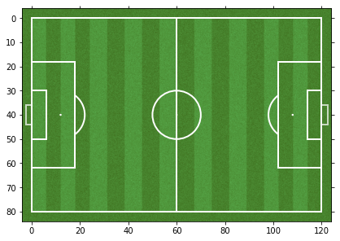

```python
pitch = Pitch(pitch_color = 'grass', line_color = 'white', stripe = True, constrained_layout = True,
        tight_layout = False, goal_type = 'box', label = True,  axis = True, tick = True)
fig, ax = pitch.draw()
plt.show()
```

- Let us try to understand what is happening here. Personally, I like setting the `pitch_color` argument to `'grass'` giving an impression of a real life football pitch. Note that any other color can be set, for example, `'black'` or any color represented by its hex code. Discarding the `stripe` argument removes the darker stripes that appear on the pitch. The `line_color` is self-explanatory and the user can change its color too according to their need. By default, the axis, labels and the ticks representing the scales are switched off. The user can turn it on by setting `label`, `axis` and `tick` arguments to be `True`, as evident in the above pitch. Let us draw a different pitch with its color changed and stripes removed.

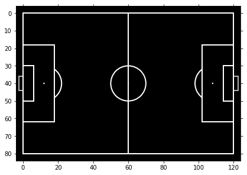

```python
pitch = Pitch(pitch_color='black', line_color = 'white', constrained_layout = True,
        tight_layout = False, goal_type = 'box', label = True,  axis = True, tick = True)
fig, ax = pitch.draw()
plt.show()
```

- Now let us focus on the axis range for a moment. By default the `Pitch()` function sets the pitch type to be `statsbomb` where the y-axis is inverted and ranges from `80` to `0`. The x-axis ranges from `0` to `120`. We will be mostly working with statsbomb data, so, these orientations of the axes won't be of much concern. Nevertheless this information is way too useful and we must keep this in mind, in case we deal with football data from other sources.
- To be precise, there are eight different pitch types that `mplsoccer` provides us with. They are `'statsbomb'`, `'opta'`, `'tracab'`, `'skillcorner'`, `'wyscout'`,`'metricasports'`, `'uefa'`, and `'custom'`. This can be set using the `pitch_type` argument inside the `Pitch()` function. Let us check the orientation of the `uefa` pitch type:

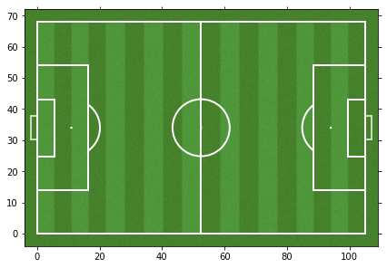

```python
pitch = Pitch(pitch_color='grass', stripe = True, pitch_type = 'uefa', line_color = 'white', constrained_layout = True,
        tight_layout = False, goal_type = 'box', label = True,  axis = True, tick = True)
fig, ax = pitch.draw()
plt.show()
```

- The reader might have noticed that by default, the pitch has a horizontal appearance. If the user wants it to be vertical, they should pass an additional argument `orientation` and set it to `'vertical'`.

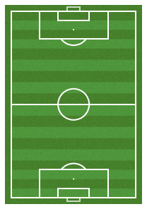

```python
pitch = Pitch(orientation = 'vertical', pitch_color = 'grass', line_color = 'white', stripe = True, constrained_layout = True,
        tight_layout = False, goal_type = 'box')
fig, ax = pitch.draw()
plt.show()
```

- The user can also make the pitch appear half by setting the `view` argument to be `'half'`.

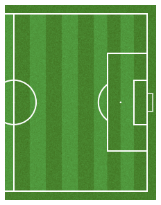

```python
pitch = Pitch(view = 'half', pitch_color = 'grass', line_color = 'white', stripe = True, constrained_layout = True,
        tight_layout = False, goal_type = 'box')
fig, ax = pitch.draw()
plt.show()
```

- These are the most basic concepts covering the topic of drawing and visualizing a football pitch using `mplsoccer`. The pitches can be further customized to meet the users' visualization needs. Keep an eye on the `mplsoccer` documentation to learn more about the same. In the next section, we will learn how to visualize a pass network for a particular team from a match and analyze the network with the help of *NetworkX* Python package. This package will help us use basic concepts from complex network analysis literature to analyze the network and deduce some interesting properties from the same.

## Visualize a Pass Network

- We will employ the [`NetworkX`](https://networkx.org/) Python package for the analysis purpose. Let us `pip` install the package:

```python
pip install networkx
```

- After installing the package we will import `networkx`:

```python
import networkx as nx
```

- We will also `pip` install the [`seaborn`](https://seaborn.pydata.org/) package which is a Python package built on `matplotlib` and is used for generating informative and appealing statistical graphs for analysis purposes.

```python
pip install seaborn
```

- Let's import `seaborn` too

```python
import seaborn as sns
```

- If we look into the `events` dataset, we notice that there is a column named `tactics` that provides us with team lineups, formations, player ids and their jersey number from both the teams. The corresponding row values for column `type` gives us an idea about whether it was the starting 11 formation or was a tactical shift or any other developments in the teams. Let us generate a completely new dataset only focusing on the `tactics` and the `type` columns. We will filter the data in such a way that the `tactics` column has no rows set to `nan`.

```python
tact = events[events['tactics'].isnull() == False]
tact = tact[['tactics', 'team', 'type']]
```

- The `tact` dataset looks like:

```python
tact
```

|  | tactics | team | type |
| --- | --- | --- | --- |
| 0 | {'formation': 41212, 'lineup': [{'player': {'i... | Real Madrid | Starting XI |
| 1 | {'formation': 433, 'lineup': [{'player': {'id'... | Liverpool | Starting XI |
| 3489 | {'formation': 433, 'lineup': [{'player': {'id'... | Liverpool | Tactical Shift |
| 3490 | {'formation': 433, 'lineup': [{'player': {'id'... | Real Madrid | Tactical Shift |
| 3491 | {'formation': 433, 'lineup': [{'player': {'id'... | Real Madrid | Tactical Shift |

- Let us focus only on the tactics for the starting 11 set up from both the teams. We will build and analyze the pass network generated from among the starting 11 players from either of the teams. If we look into the first two rows of the `type` column in `tact`, we see that they are set as `'Starting XI'`, one for each team. Let us separately fetch the data for the teams, filtering by `type`

```python
tact = tact[tact['type'] == 'Starting XI']
tact_Real = tact[tact['team'] == 'Real Madrid']
tact_Liv = tact[tact['team'] == 'Liverpool']
tact_Real = tact_Real['tactics']
tact_Liv = tact_Liv['tactics']
```

- So both `tact_Real` and `tact_Liv` are dataframes made of single rows with their indices (Which we will use to extract the data), and the `tactics` column is made up of a Python `dict` object. For now we are only interested in the key `'lineup'` to get all the information about the players from the teams.

```python
dict_Real = tact_Real[0]['lineup']
dict_Liv = tact_Liv[1]['lineup']
```

- We will use the `from_dict()` function provided by `pandas` to convert the dictionary into a dataframe.

```python
lineup_Real = pd.DataFrame.from_dict(dict_Real)
lineup_Real
```

|  | player | position | jersey_number |
| --- | --- | --- | --- |
| 0 | {'id': 5597, 'name': 'Keylor Navas Gamboa'} | {'id': 1, 'name': 'Goalkeeper'} | 1 |
| 1 | {'id': 5721, 'name': 'Daniel Carvajal Ramos'} | {'id': 2, 'name': 'Right Back'} | 2 |
| 2 | {'id': 5485, 'name': 'Raphaël Varane'} | {'id': 3, 'name': 'Right Center Back'} | 5 |
| 3 | {'id': 5201, 'name': 'Sergio Ramos García'} | {'id': 5, 'name': 'Left Center Back'} | 4 |
| 4 | {'id': 5552, 'name': 'Marcelo Vieira da Silva ... | {'id': 6, 'name': 'Left Back'} | 12 |
| 5 | {'id': 5539, 'name': 'Carlos Henrique Casimiro'} | {'id': 10, 'name': 'Center Defensive Midfield'} | 14 |
| 6 | {'id': 5463, 'name': 'Luka Modrić'} | {'id': 13, 'name': 'Right Center Midfield'} | 10 |
| 7 | {'id': 5574, 'name': 'Toni Kroos'} | {'id': 15, 'name': 'Left Center Midfield'} | 8 |
| 8 | {'id': 4926, 'name': 'Francisco Román Alarcón ... | {'id': 19, 'name': 'Center Attacking Midfield'} | 22 |
| 9 | {'id': 19677, 'name': 'Karim Benzema'} | {'id': 22, 'name': 'Right Center Forward'} | 9 |
| 10 | {'id': 5207, 'name': 'Cristiano Ronaldo dos Sa... | {'id': 24, 'name': 'Left Center Forward'} | 7 |

```python
lineup_Liv = pd.DataFrame.from_dict(dict_Liv)
lineup_Liv
```

|  | player | position | jersey_number |
| --- | --- | --- | --- |
| 0 | {'id': 3630, 'name': 'Loris Karius'} | {'id': 1, 'name': 'Goalkeeper'} | 1 |
| 1 | {'id': 3664, 'name': 'Trent Alexander-Arnold'} | {'id': 2, 'name': 'Right Back'} | 66 |
| 2 | {'id': 3471, 'name': 'Dejan Lovren'} | {'id': 3, 'name': 'Right Center Back'} | 6 |
| 3 | {'id': 3669, 'name': 'Virgil van Dijk'} | {'id': 5, 'name': 'Left Center Back'} | 4 |
| 4 | {'id': 3655, 'name': 'Andrew Robertson'} | {'id': 6, 'name': 'Left Back'} | 26 |
| 5 | {'id': 3532, 'name': 'Jordan Brian Henderson'} | {'id': 10, 'name': 'Center Defensive Midfield'} | 14 |
| 6 | {'id': 3567, 'name': 'Georginio Wijnaldum'} | {'id': 13, 'name': 'Right Center Midfield'} | 5 |
| 7 | {'id': 3473, 'name': 'James Philip Milner'} | {'id': 15, 'name': 'Left Center Midfield'} | 7 |
| 8 | {'id': 3531, 'name': 'Mohamed Salah'} | {'id': 17, 'name': 'Right Wing'} | 11 |
| 9 | {'id': 3629, 'name': 'Sadio Mané'} | {'id': 21, 'name': 'Left Wing'} | 19 |
| 10 | {'id': 3535, 'name': 'Roberto Firmino Barbosa ... | {'id': 23, 'name': 'Center Forward'} | 9 |

- We are basically interested in the players name and their corresponding jersey numbers. We will use a simple for loop and store the information in seperate dictionaries for both the teams.

```python
players_Real = {}
for i in range(len(lineup_Real)):
    key = lineup_Real.player[i]['name']
    val = lineup_Real.jersey_number[i]
    players_Real[key] = str(val)
print(players_Real)
```

[output not shown]

```python
players_Liv = {}
for i in range(len(lineup_Liv)):
    key = lineup_Liv.player[i]['name']
    val = lineup_Liv.jersey_number[i]
    players_Liv[key] = str(val)
print(players_Liv)
```

```
{'Loris Karius': '1', 'Trent Alexander-Arnold': '66', 'Dejan Lovren': '6', 'Virgil van Dijk': '4', 'Andrew Robertson': '26', 'Jordan Brian Henderson': '14', 'Georginio Wijnaldum': '5', 'James Philip Milner': '7', 'Mohamed Salah': '11', 'Sadio Mané': '19', 'Roberto Firmino Barbosa de Oliveira': '9'}
```

- So, we have collected the names and the jersey number of the players (starting 11) from both the teams in separate dictionaries named `players_Real` and `players_Liv`. These will come handy later!
- Now from the `events` dataset we will extract out the relevant columns for our pass network analysis purposes.

```python
events_pn = events[['minute', 'second', 'team', 'type', 'location', 'pass_end_location', 'pass_outcome', 'player']]
```

- The first 10 rows of the `events_pn` dataframe:

```python
events_pn.head(10)
```

|  | minute | second | team | type | location | pass_end_location | pass_outcome | player |
| --- | --- | --- | --- | --- | --- | --- | --- | --- |
| 0 | 0 | 0 | Real Madrid | Starting XI | NaN | NaN | NaN | NaN |
| 1 | 0 | 0 | Liverpool | Starting XI | NaN | NaN | NaN | NaN |
| 2 | 0 | 0 | Real Madrid | Half Start | NaN | NaN | NaN | NaN |
| 3 | 0 | 0 | Liverpool | Half Start | NaN | NaN | NaN | NaN |
| 4 | 45 | 0 | Liverpool | Half Start | NaN | NaN | NaN | NaN |
| 5 | 45 | 0 | Real Madrid | Half Start | NaN | NaN | NaN | NaN |
| 6 | 0 | 0 | Liverpool | Pass | [60.0, 40.0] | [32.1, 41.2] | NaN | James Philip Milner |
| 7 | 0 | 3 | Liverpool | Pass | [35.0, 40.8] | [92.7, 22.7] | Incomplete | Dejan Lovren |
| 8 | 0 | 8 | Real Madrid | Pass | [27.4, 60.2] | [36.1, 71.6] | NaN | Raphaël Varane |
| 9 | 0 | 10 | Real Madrid | Pass | [35.3, 75.4] | [22.4, 76.6] | NaN | Luka Modrić |

- The last 10 rows of the `events_pn` dataframe:

```python
events_pn.tail(10)
```

|  | minute | second | team | type | location | pass_end_location | pass_outcome | player |
| --- | --- | --- | --- | --- | --- | --- | --- | --- |
| 3487 | 82 | 27 | Liverpool | Substitution | NaN | NaN | NaN | James Philip Milner |
| 3488 | 88 | 21 | Real Madrid | Substitution | NaN | NaN | NaN | Karim Benzema |
| 3489 | 31 | 41 | Liverpool | Tactical Shift | NaN | NaN | NaN | NaN |
| 3490 | 61 | 1 | Real Madrid | Tactical Shift | NaN | NaN | NaN | NaN |
| 3491 | 88 | 34 | Real Madrid | Tactical Shift | NaN | NaN | NaN | NaN |
| 3492 | 42 | 21 | Real Madrid | Offside | [114.8, 41.4] | NaN | NaN | Karim Benzema |
| 3493 | 48 | 31 | Real Madrid | Half End | NaN | NaN | NaN | NaN |
| 3494 | 48 | 31 | Liverpool | Half End | NaN | NaN | NaN | NaN |
| 3495 | 93 | 2 | Liverpool | Half End | NaN | NaN | NaN | NaN |
| 3496 | 93 | 2 | Real Madrid | Half End | NaN | NaN | NaN | NaN |

- The next step is to filter the datset by teams and store them as new datasets:

```python
events_Real = events_pn[events_pn['team'] == 'Real Madrid']
events_Liv = events_pn[events_pn['team'] == 'Liverpool']
```

View the first 10 rows from both the datasets:

```python
events_Real.head(10)
```

|  | minute | second | team | type | location | pass_end_location | pass_outcome | player |
| --- | --- | --- | --- | --- | --- | --- | --- | --- |
| 0 | 0 | 0 | Real Madrid | Starting XI | NaN | NaN | NaN | NaN |
| 2 | 0 | 0 | Real Madrid | Half Start | NaN | NaN | NaN | NaN |
| 5 | 45 | 0 | Real Madrid | Half Start | NaN | NaN | NaN | NaN |
| 8 | 0 | 8 | Real Madrid | Pass | [27.4, 60.2] | [36.1, 71.6] | NaN | Raphaël Varane |
| 9 | 0 | 10 | Real Madrid | Pass | [35.3, 75.4] | [22.4, 76.6] | NaN | Luka Modrić |
| 10 | 0 | 11 | Real Madrid | Pass | [22.3, 76.6] | [33.4, 68.0] | NaN | Daniel Carvajal Ramos |
| 11 | 0 | 15 | Real Madrid | Pass | [36.2, 75.3] | [43.6, 62.0] | Incomplete | Carlos Henrique Casimiro |
| 16 | 0 | 25 | Real Madrid | Pass | [14.7, 23.2] | [56.7, 6.2] | Incomplete | Sergio Ramos García |
| 17 | 0 | 40 | Real Madrid | Pass | [57.5, 4.6] | [49.2, 15.6] | NaN | Marcelo Vieira da Silva Júnior |
| 18 | 0 | 43 | Real Madrid | Pass | [48.8, 18.4] | [49.8, 12.5] | NaN | Carlos Henrique Casimiro |

```python
events_Liv.head(10)
```

|  | minute | second | team | type | location | pass_end_location | pass_outcome | player |
| --- | --- | --- | --- | --- | --- | --- | --- | --- |
| 1 | 0 | 0 | Liverpool | Starting XI | NaN | NaN | NaN | NaN |
| 3 | 0 | 0 | Liverpool | Half Start | NaN | NaN | NaN | NaN |
| 4 | 45 | 0 | Liverpool | Half Start | NaN | NaN | NaN | NaN |
| 6 | 0 | 0 | Liverpool | Pass | [60.0, 40.0] | [32.1, 41.2] | NaN | James Philip Milner |
| 7 | 0 | 3 | Liverpool | Pass | [35.0, 40.8] | [92.7, 22.7] | Incomplete | Dejan Lovren |
| 12 | 0 | 16 | Liverpool | Pass | [76.5, 18.1] | [84.8, 9.5] | NaN | Jordan Brian Henderson |
| 13 | 0 | 18 | Liverpool | Pass | [84.4, 10.0] | [92.5, 19.1] | NaN | Sadio Mané |
| 14 | 0 | 19 | Liverpool | Pass | [91.6, 21.3] | [90.6, 50.7] | NaN | Roberto Firmino Barbosa de Oliveira |
| 15 | 0 | 22 | Liverpool | Pass | [92.2, 50.9] | [109.7, 46.4] | Incomplete | Mohamed Salah |
| 25 | 1 | 7 | Liverpool | Pass | [42.0, 75.9] | [115.6, 59.3] | Incomplete | Trent Alexander-Arnold |

- As we are only interested in the pass network generation, we will filter the datasets by keeping those rows where `type` is set to `Pass`.

```python
events_pn_Real = events_Real[events_Real['type'] == 'Pass']
events_pn_Liv = events_Liv[events_Liv['type'] == 'Pass']
```

- Again view the first 10 rows of the filtered datasets:

```python
events_pn_Real.head(10)
```

|  | minute | second | team | type | location | pass_end_location | pass_outcome | player |
| --- | --- | --- | --- | --- | --- | --- | --- | --- |
| 8 | 0 | 8 | Real Madrid | Pass | [27.4, 60.2] | [36.1, 71.6] | NaN | Raphaël Varane |
| 9 | 0 | 10 | Real Madrid | Pass | [35.3, 75.4] | [22.4, 76.6] | NaN | Luka Modrić |
| 10 | 0 | 11 | Real Madrid | Pass | [22.3, 76.6] | [33.4, 68.0] | NaN | Daniel Carvajal Ramos |
| 11 | 0 | 15 | Real Madrid | Pass | [36.2, 75.3] | [43.6, 62.0] | Incomplete | Carlos Henrique Casimiro |
| 16 | 0 | 25 | Real Madrid | Pass | [14.7, 23.2] | [56.7, 6.2] | Incomplete | Sergio Ramos García |
| 17 | 0 | 40 | Real Madrid | Pass | [57.5, 4.6] | [49.2, 15.6] | NaN | Marcelo Vieira da Silva Júnior |
| 18 | 0 | 43 | Real Madrid | Pass | [48.8, 18.4] | [49.8, 12.5] | NaN | Carlos Henrique Casimiro |
| 19 | 0 | 46 | Real Madrid | Pass | [48.8, 13.9] | [36.1, 56.3] | NaN | Toni Kroos |
| 20 | 0 | 52 | Real Madrid | Pass | [41.3, 54.8] | [34.4, 40.2] | NaN | Raphaël Varane |
| 21 | 0 | 55 | Real Madrid | Pass | [39.1, 36.5] | [65.4, 13.1] | NaN | Sergio Ramos García |

```python
events_pn_Liv.head(10)
```

|  | minute | second | team | type | location | pass_end_location | pass_outcome | player |
| --- | --- | --- | --- | --- | --- | --- | --- | --- |
| 6 | 0 | 0 | Liverpool | Pass | [60.0, 40.0] | [32.1, 41.2] | NaN | James Philip Milner |
| 7 | 0 | 3 | Liverpool | Pass | [35.0, 40.8] | [92.7, 22.7] | Incomplete | Dejan Lovren |
| 12 | 0 | 16 | Liverpool | Pass | [76.5, 18.1] | [84.8, 9.5] | NaN | Jordan Brian Henderson |
| 13 | 0 | 18 | Liverpool | Pass | [84.4, 10.0] | [92.5, 19.1] | NaN | Sadio Mané |
| 14 | 0 | 19 | Liverpool | Pass | [91.6, 21.3] | [90.6, 50.7] | NaN | Roberto Firmino Barbosa de Oliveira |
| 15 | 0 | 22 | Liverpool | Pass | [92.2, 50.9] | [109.7, 46.4] | Incomplete | Mohamed Salah |
| 25 | 1 | 7 | Liverpool | Pass | [42.0, 75.9] | [115.6, 59.3] | Incomplete | Trent Alexander-Arnold |
| 37 | 2 | 0 | Liverpool | Pass | [9.9, 39.1] | [28.1, 4.2] | NaN | Virgil van Dijk |
| 38 | 2 | 3 | Liverpool | Pass | [43.2, 2.8] | [50.1, 4.8] | Incomplete | Andrew Robertson |
| 39 | 2 | 7 | Liverpool | Pass | [53.2, 0.1] | [50.0, 4.0] | NaN | Andrew Robertson |

- Let us now very carefully observe the datasets. Suppose from the `events_pn_Real` dataset, we are focusing on the second and the third row (index `1` and `2`). `Luka Modrić` makes the pass at around `0`th `minute` and `10`th `second` (Second row) and `Daniel Carvajal Ramos` receives the pass at around `0`th `minute` and `11`th `second` (third row). So in both the datasets we need to add two extra columns named as `pass_maker` and `pass_receiver`, where `pass_maker` column would be similar to `player` column and the `pass_receiver` column would be the `player` column whose index would be shifted by one place in the negative direction. This can be achieved by the `shift()` function provided by `pandas`. We will perform this operation on both `events_pn_Real` and `events_pn_Liv`.

```python
events_pn_Real['pass_maker'] = events_pn_Real['player']
events_pn_Real['pass_receiver'] = events_pn_Real['player'].shift(-1)

events_pn_Liv['pass_maker'] = events_pn_Liv['player']
events_pn_Liv['pass_receiver'] = events_pn_Liv['player'].shift(-1)
```

- Let us check now how the modified datasets look:

```python
events_pn_Real.head(10)
```

|  | minute | second | team | type | location | pass_end_location | pass_outcome | player | pass_maker | pass_receiver |
| --- | --- | --- | --- | --- | --- | --- | --- | --- | --- | --- |
| 8 | 0 | 8 | Real Madrid | Pass | [27.4, 60.2] | [36.1, 71.6] | NaN | Raphaël Varane | Raphaël Varane | Luka Modrić |
| 9 | 0 | 10 | Real Madrid | Pass | [35.3, 75.4] | [22.4, 76.6] | NaN | Luka Modrić | Luka Modrić | Daniel Carvajal Ramos |
| 10 | 0 | 11 | Real Madrid | Pass | [22.3, 76.6] | [33.4, 68.0] | NaN | Daniel Carvajal Ramos | Daniel Carvajal Ramos | Carlos Henrique Casimiro |
| 11 | 0 | 15 | Real Madrid | Pass | [36.2, 75.3] | [43.6, 62.0] | Incomplete | Carlos Henrique Casimiro | Carlos Henrique Casimiro | Sergio Ramos García |
| 16 | 0 | 25 | Real Madrid | Pass | [14.7, 23.2] | [56.7, 6.2] | Incomplete | Sergio Ramos García | Sergio Ramos García | Marcelo Vieira da Silva Júnior |
| 17 | 0 | 40 | Real Madrid | Pass | [57.5, 4.6] | [49.2, 15.6] | NaN | Marcelo Vieira da Silva Júnior | Marcelo Vieira da Silva Júnior | Carlos Henrique Casimiro |
| 18 | 0 | 43 | Real Madrid | Pass | [48.8, 18.4] | [49.8, 12.5] | NaN | Carlos Henrique Casimiro | Carlos Henrique Casimiro | Toni Kroos |
| 19 | 0 | 46 | Real Madrid | Pass | [48.8, 13.9] | [36.1, 56.3] | NaN | Toni Kroos | Toni Kroos | Raphaël Varane |
| 20 | 0 | 52 | Real Madrid | Pass | [41.3, 54.8] | [34.4, 40.2] | NaN | Raphaël Varane | Raphaël Varane | Sergio Ramos García |
| 21 | 0 | 55 | Real Madrid | Pass | [39.1, 36.5] | [65.4, 13.1] | NaN | Sergio Ramos García | Sergio Ramos García | Cristiano Ronaldo dos Santos Aveiro |

```python
events_pn_Liv.head(10)
```

|  | minute | second | team | type | location | pass_end_location | pass_outcome | player | pass_maker | pass_receiver |
| --- | --- | --- | --- | --- | --- | --- | --- | --- | --- | --- |
| 6 | 0 | 0 | Liverpool | Pass | [60.0, 40.0] | [32.1, 41.2] | NaN | James Philip Milner | James Philip Milner | Dejan Lovren |
| 7 | 0 | 3 | Liverpool | Pass | [35.0, 40.8] | [92.7, 22.7] | Incomplete | Dejan Lovren | Dejan Lovren | Jordan Brian Henderson |
| 12 | 0 | 16 | Liverpool | Pass | [76.5, 18.1] | [84.8, 9.5] | NaN | Jordan Brian Henderson | Jordan Brian Henderson | Sadio Mané |
| 13 | 0 | 18 | Liverpool | Pass | [84.4, 10.0] | [92.5, 19.1] | NaN | Sadio Mané | Sadio Mané | Roberto Firmino Barbosa de Oliveira |
| 14 | 0 | 19 | Liverpool | Pass | [91.6, 21.3] | [90.6, 50.7] | NaN | Roberto Firmino Barbosa de Oliveira | Roberto Firmino Barbosa de Oliveira | Mohamed Salah |
| 15 | 0 | 22 | Liverpool | Pass | [92.2, 50.9] | [109.7, 46.4] | Incomplete | Mohamed Salah | Mohamed Salah | Trent Alexander-Arnold |
| 25 | 1 | 7 | Liverpool | Pass | [42.0, 75.9] | [115.6, 59.3] | Incomplete | Trent Alexander-Arnold | Trent Alexander-Arnold | Virgil van Dijk |
| 37 | 2 | 0 | Liverpool | Pass | [9.9, 39.1] | [28.1, 4.2] | NaN | Virgil van Dijk | Virgil van Dijk | Andrew Robertson |
| 38 | 2 | 3 | Liverpool | Pass | [43.2, 2.8] | [50.1, 4.8] | Incomplete | Andrew Robertson | Andrew Robertson | Andrew Robertson |
| 39 | 2 | 7 | Liverpool | Pass | [53.2, 0.1] | [50.0, 4.0] | NaN | Andrew Robertson | Andrew Robertson | James Philip Milner |

- Now, there might be passes which were not successful. Note that in the statsbomb data passes whose `pass_outcome` are set as `nan` are actually the successful passes. We will again filter the datasets by successful passes:

```python
events_pn_Real = events_pn_Real[events_pn_Real['pass_outcome'].isnull() == True].reset_index()
events_pn_Liv = events_pn_Liv[events_pn_Liv['pass_outcome'].isnull() == True].reset_index()
```

- The first 10 rows of the filtered datasets:

```python
events_pn_Real.head(10)
```

|  | index | minute | second | team | type | location | pass_end_location | pass_outcome | player | pass_maker | pass_receiver |
| --- | --- | --- | --- | --- | --- | --- | --- | --- | --- | --- | --- |
| 0 | 8 | 0 | 8 | Real Madrid | Pass | [27.4, 60.2] | [36.1, 71.6] | NaN | Raphaël Varane | Raphaël Varane | Luka Modrić |
| 1 | 9 | 0 | 10 | Real Madrid | Pass | [35.3, 75.4] | [22.4, 76.6] | NaN | Luka Modrić | Luka Modrić | Daniel Carvajal Ramos |
| 2 | 10 | 0 | 11 | Real Madrid | Pass | [22.3, 76.6] | [33.4, 68.0] | NaN | Daniel Carvajal Ramos | Daniel Carvajal Ramos | Carlos Henrique Casimiro |
| 3 | 17 | 0 | 40 | Real Madrid | Pass | [57.5, 4.6] | [49.2, 15.6] | NaN | Marcelo Vieira da Silva Júnior | Marcelo Vieira da Silva Júnior | Carlos Henrique Casimiro |
| 4 | 18 | 0 | 43 | Real Madrid | Pass | [48.8, 18.4] | [49.8, 12.5] | NaN | Carlos Henrique Casimiro | Carlos Henrique Casimiro | Toni Kroos |
| 5 | 19 | 0 | 46 | Real Madrid | Pass | [48.8, 13.9] | [36.1, 56.3] | NaN | Toni Kroos | Toni Kroos | Raphaël Varane |
| 6 | 20 | 0 | 52 | Real Madrid | Pass | [41.3, 54.8] | [34.4, 40.2] | NaN | Raphaël Varane | Raphaël Varane | Sergio Ramos García |
| 7 | 21 | 0 | 55 | Real Madrid | Pass | [39.1, 36.5] | [65.4, 13.1] | NaN | Sergio Ramos García | Sergio Ramos García | Cristiano Ronaldo dos Santos Aveiro |
| 8 | 22 | 0 | 58 | Real Madrid | Pass | [64.5, 11.1] | [54.2, 5.6] | NaN | Cristiano Ronaldo dos Santos Aveiro | Cristiano Ronaldo dos Santos Aveiro | Marcelo Vieira da Silva Júnior |
| 9 | 23 | 0 | 59 | Real Madrid | Pass | [55.3, 5.5] | [83.9, 4.3] | NaN | Marcelo Vieira da Silva Júnior | Marcelo Vieira da Silva Júnior | Karim Benzema |

```python
events_pn_Liv.head(10)
```

|  | index | minute | second | team | type | location | pass_end_location | pass_outcome | player | pass_maker | pass_receiver |
| --- | --- | --- | --- | --- | --- | --- | --- | --- | --- | --- | --- |
| 0 | 6 | 0 | 0 | Liverpool | Pass | [60.0, 40.0] | [32.1, 41.2] | NaN | James Philip Milner | James Philip Milner | Dejan Lovren |
| 1 | 12 | 0 | 16 | Liverpool | Pass | [76.5, 18.1] | [84.8, 9.5] | NaN | Jordan Brian Henderson | Jordan Brian Henderson | Sadio Mané |
| 2 | 13 | 0 | 18 | Liverpool | Pass | [84.4, 10.0] | [92.5, 19.1] | NaN | Sadio Mané | Sadio Mané | Roberto Firmino Barbosa de Oliveira |
| 3 | 14 | 0 | 19 | Liverpool | Pass | [91.6, 21.3] | [90.6, 50.7] | NaN | Roberto Firmino Barbosa de Oliveira | Roberto Firmino Barbosa de Oliveira | Mohamed Salah |
| 4 | 37 | 2 | 0 | Liverpool | Pass | [9.9, 39.1] | [28.1, 4.2] | NaN | Virgil van Dijk | Virgil van Dijk | Andrew Robertson |
| 5 | 39 | 2 | 7 | Liverpool | Pass | [53.2, 0.1] | [50.0, 4.0] | NaN | Andrew Robertson | Andrew Robertson | James Philip Milner |
| 6 | 40 | 2 | 10 | Liverpool | Pass | [45.5, 4.0] | [27.4, 16.8] | NaN | James Philip Milner | James Philip Milner | Virgil van Dijk |
| 7 | 41 | 2 | 13 | Liverpool | Pass | [26.7, 19.6] | [27.8, 47.3] | NaN | Virgil van Dijk | Virgil van Dijk | Dejan Lovren |
| 8 | 42 | 2 | 16 | Liverpool | Pass | [28.0, 45.4] | [28.4, 21.4] | NaN | Dejan Lovren | Dejan Lovren | Virgil van Dijk |
| 9 | 43 | 2 | 19 | Liverpool | Pass | [30.4, 25.7] | [30.7, 52.9] | NaN | Virgil van Dijk | Virgil van Dijk | Dejan Lovren |

- So it seems we have been able to logically clean and modify the datasets. Now we are only focused on building the pass network among the players who were in the starting 11 from both the teams. So we will discard out the rows which consist of pass events that took place after the first substitution for either of the teams. Let us find the `minute` and `second` of the first substitution for both `Real Madrid` and `Liverpool`.
- Now, let us filter the datasets `events_Real` and `events_Liv` by setting the `type` to be `Substitution`. This will give us the information of when the first substitution had taken place for the teams.

```python
substitution_Real = events_Real[events_Real['type'] == 'Substitution']
substitution_Liv = events_Liv[events_Liv['type'] == 'Substitution']
```

- And let us view the datasets:

```python
substitution_Real
```

|  | minute | second | team | type | location | pass_end_location | pass_outcome | player |
| --- | --- | --- | --- | --- | --- | --- | --- | --- |
| 3485 | 36 | 17 | Real Madrid | Substitution | NaN | NaN | NaN | Daniel Carvajal Ramos |
| 3486 | 60 | 56 | Real Madrid | Substitution | NaN | NaN | NaN | Francisco Román Alarcón Suárez |
| 3488 | 88 | 21 | Real Madrid | Substitution | NaN | NaN | NaN | Karim Benzema |

```python
substitution_Liv
```

|  | minute | second | team | type | location | pass_end_location | pass_outcome | player |
| --- | --- | --- | --- | --- | --- | --- | --- | --- |
| 3484 | 29 | 39 | Liverpool | Substitution | NaN | NaN | NaN | Mohamed Salah |
| 3487 | 82 | 27 | Liverpool | Substitution | NaN | NaN | NaN | James Philip Milner |

- We see that the first substitution takes place for `Real Madrid` at the `36`th minute and `17`th second, whereas for `Liverpool` it takes place around `29`th minute and `39`th second. Let us find these out by writing a small Python code:

```python
substitution_Real_minute = np.min(substitution_Real['minute'])
substitution_Real_minute_data = substitution_Real[substitution_Real['minute'] == substitution_Real_minute]
substitution_Real_second = np.min(substitution_Real_minute_data['second'])
print("minute =", substitution_Real_minute, "second =",  substitution_Real_second)
```

```
minute = 36 second = 17
```

```python
substitution_Liv_minute = np.min(substitution_Liv['minute'])
substitution_Liv_minute_data = substitution_Liv[substitution_Liv['minute'] == substitution_Liv_minute]
substitution_Liv_second = np.min(substitution_Liv_minute_data['second'])
print("minute = ", substitution_Liv_minute, "second = ", substitution_Liv_second)
```

```
minute =  29 second =  39
```

- We see that we have gotten the correct timings of when the first substitutions had taken place. Now we filter our datasets by taking tose pass events that took place before the first substitutions

```python
events_pn_Real = events_pn_Real[(events_pn_Real['minute'] <= substitution_Real_minute)]

events_pn_Liv = events_pn_Liv[(events_pn_Liv['minute'] <= substitution_Liv_minute)]
```

- Let us again print the first 10 rows of the renewed datasets:

```python
events_pn_Real.head(10)
```

|  | index | minute | second | team | type | location | pass_end_location | pass_outcome | player | pass_maker | pass_receiver |
| --- | --- | --- | --- | --- | --- | --- | --- | --- | --- | --- | --- |
| 0 | 8 | 0 | 8 | Real Madrid | Pass | [27.4, 60.2] | [36.1, 71.6] | NaN | Raphaël Varane | Raphaël Varane | Luka Modrić |
| 1 | 9 | 0 | 10 | Real Madrid | Pass | [35.3, 75.4] | [22.4, 76.6] | NaN | Luka Modrić | Luka Modrić | Daniel Carvajal Ramos |
| 2 | 10 | 0 | 11 | Real Madrid | Pass | [22.3, 76.6] | [33.4, 68.0] | NaN | Daniel Carvajal Ramos | Daniel Carvajal Ramos | Carlos Henrique Casimiro |
| 3 | 17 | 0 | 40 | Real Madrid | Pass | [57.5, 4.6] | [49.2, 15.6] | NaN | Marcelo Vieira da Silva Júnior | Marcelo Vieira da Silva Júnior | Carlos Henrique Casimiro |
| 4 | 18 | 0 | 43 | Real Madrid | Pass | [48.8, 18.4] | [49.8, 12.5] | NaN | Carlos Henrique Casimiro | Carlos Henrique Casimiro | Toni Kroos |
| 5 | 19 | 0 | 46 | Real Madrid | Pass | [48.8, 13.9] | [36.1, 56.3] | NaN | Toni Kroos | Toni Kroos | Raphaël Varane |
| 6 | 20 | 0 | 52 | Real Madrid | Pass | [41.3, 54.8] | [34.4, 40.2] | NaN | Raphaël Varane | Raphaël Varane | Sergio Ramos García |
| 7 | 21 | 0 | 55 | Real Madrid | Pass | [39.1, 36.5] | [65.4, 13.1] | NaN | Sergio Ramos García | Sergio Ramos García | Cristiano Ronaldo dos Santos Aveiro |
| 8 | 22 | 0 | 58 | Real Madrid | Pass | [64.5, 11.1] | [54.2, 5.6] | NaN | Cristiano Ronaldo dos Santos Aveiro | Cristiano Ronaldo dos Santos Aveiro | Marcelo Vieira da Silva Júnior |
| 9 | 23 | 0 | 59 | Real Madrid | Pass | [55.3, 5.5] | [83.9, 4.3] | NaN | Marcelo Vieira da Silva Júnior | Marcelo Vieira da Silva Júnior | Karim Benzema |

```python
events_pn_Liv.head(10)
```

|  | index | minute | second | team | type | location | pass_end_location | pass_outcome | player | pass_maker | pass_receiver |
| --- | --- | --- | --- | --- | --- | --- | --- | --- | --- | --- | --- |
| 0 | 6 | 0 | 0 | Liverpool | Pass | [60.0, 40.0] | [32.1, 41.2] | NaN | James Philip Milner | James Philip Milner | Dejan Lovren |
| 1 | 12 | 0 | 16 | Liverpool | Pass | [76.5, 18.1] | [84.8, 9.5] | NaN | Jordan Brian Henderson | Jordan Brian Henderson | Sadio Mané |
| 2 | 13 | 0 | 18 | Liverpool | Pass | [84.4, 10.0] | [92.5, 19.1] | NaN | Sadio Mané | Sadio Mané | Roberto Firmino Barbosa de Oliveira |
| 3 | 14 | 0 | 19 | Liverpool | Pass | [91.6, 21.3] | [90.6, 50.7] | NaN | Roberto Firmino Barbosa de Oliveira | Roberto Firmino Barbosa de Oliveira | Mohamed Salah |
| 4 | 37 | 2 | 0 | Liverpool | Pass | [9.9, 39.1] | [28.1, 4.2] | NaN | Virgil van Dijk | Virgil van Dijk | Andrew Robertson |
| 5 | 39 | 2 | 7 | Liverpool | Pass | [53.2, 0.1] | [50.0, 4.0] | NaN | Andrew Robertson | Andrew Robertson | James Philip Milner |
| 6 | 40 | 2 | 10 | Liverpool | Pass | [45.5, 4.0] | [27.4, 16.8] | NaN | James Philip Milner | James Philip Milner | Virgil van Dijk |
| 7 | 41 | 2 | 13 | Liverpool | Pass | [26.7, 19.6] | [27.8, 47.3] | NaN | Virgil van Dijk | Virgil van Dijk | Dejan Lovren |
| 8 | 42 | 2 | 16 | Liverpool | Pass | [28.0, 45.4] | [28.4, 21.4] | NaN | Dejan Lovren | Dejan Lovren | Virgil van Dijk |
| 9 | 43 | 2 | 19 | Liverpool | Pass | [30.4, 25.7] | [30.7, 52.9] | NaN | Virgil van Dijk | Virgil van Dijk | Dejan Lovren |

- Now from the datasets, we will split the `location` and the `pass_end_location` columns into two columns each representing the coordinates and name them as `pass_maker_x`, `pass_maker_y`, `pass_receiver_x` and `pass_receiver_y`.
- Let us manipulate the dataset for `Real Madrid` first:

```python
Loc = events_pn_Real['location']
Loc = pd.DataFrame(Loc.to_list(), columns=['pass_maker_x', 'pass_maker_y'])

Loc_end = events_pn_Real['pass_end_location']
Loc_end = pd.DataFrame(Loc_end.to_list(), columns=['pass_receiver_x', 'pass_receiver_y'])

events_pn_Real['pass_maker_x'] = Loc['pass_maker_x']
events_pn_Real['pass_maker_y'] = Loc['pass_maker_y']
events_pn_Real['pass_receiver_x'] = Loc_end['pass_receiver_x']
events_pn_Real['pass_receiver_y'] = Loc_end['pass_receiver_y']

events_pn_Real = events_pn_Real[['index', 'minute', 'second', 'team', 'type', 'pass_outcome',
                                 'player', 'pass_maker', 'pass_receiver', 'pass_maker_x',
                                 'pass_maker_y', 'pass_receiver_x', 'pass_receiver_y']]
```

```python
events_pn_Real.head(10)
```

|  | index | minute | second | team | type | pass_outcome | player | pass_maker | pass_receiver | pass_maker_x | pass_maker_y | pass_receiver_x | pass_receiver_y |
| --- | --- | --- | --- | --- | --- | --- | --- | --- | --- | --- | --- | --- | --- |
| 0 | 8 | 0 | 8 | Real Madrid | Pass | NaN | Raphaël Varane | Raphaël Varane | Luka Modrić | 27.4 | 60.2 | 36.1 | 71.6 |
| 1 | 9 | 0 | 10 | Real Madrid | Pass | NaN | Luka Modrić | Luka Modrić | Daniel Carvajal Ramos | 35.3 | 75.4 | 22.4 | 76.6 |
| 2 | 10 | 0 | 11 | Real Madrid | Pass | NaN | Daniel Carvajal Ramos | Daniel Carvajal Ramos | Carlos Henrique Casimiro | 22.3 | 76.6 | 33.4 | 68.0 |
| 3 | 17 | 0 | 40 | Real Madrid | Pass | NaN | Marcelo Vieira da Silva Júnior | Marcelo Vieira da Silva Júnior | Carlos Henrique Casimiro | 57.5 | 4.6 | 49.2 | 15.6 |
| 4 | 18 | 0 | 43 | Real Madrid | Pass | NaN | Carlos Henrique Casimiro | Carlos Henrique Casimiro | Toni Kroos | 48.8 | 18.4 | 49.8 | 12.5 |
| 5 | 19 | 0 | 46 | Real Madrid | Pass | NaN | Toni Kroos | Toni Kroos | Raphaël Varane | 48.8 | 13.9 | 36.1 | 56.3 |
| 6 | 20 | 0 | 52 | Real Madrid | Pass | NaN | Raphaël Varane | Raphaël Varane | Sergio Ramos García | 41.3 | 54.8 | 34.4 | 40.2 |
| 7 | 21 | 0 | 55 | Real Madrid | Pass | NaN | Sergio Ramos García | Sergio Ramos García | Cristiano Ronaldo dos Santos Aveiro | 39.1 | 36.5 | 65.4 | 13.1 |
| 8 | 22 | 0 | 58 | Real Madrid | Pass | NaN | Cristiano Ronaldo dos Santos Aveiro | Cristiano Ronaldo dos Santos Aveiro | Marcelo Vieira da Silva Júnior | 64.5 | 11.1 | 54.2 | 5.6 |
| 9 | 23 | 0 | 59 | Real Madrid | Pass | NaN | Marcelo Vieira da Silva Júnior | Marcelo Vieira da Silva Júnior | Karim Benzema | 55.3 | 5.5 | 83.9 | 4.3 |

- Same data manipulation for Liverpool:

```python
Loc = events_pn_Liv['location']
Loc = pd.DataFrame(Loc.to_list(), columns=['pass_maker_x', 'pass_maker_y'])

Loc_end = events_pn_Liv['pass_end_location']
Loc_end = pd.DataFrame(Loc_end.to_list(), columns=['pass_receiver_x', 'pass_receiver_y'])

events_pn_Liv['pass_maker_x'] = Loc['pass_maker_x']
events_pn_Liv['pass_maker_y'] = Loc['pass_maker_y']
events_pn_Liv['pass_receiver_x'] = Loc_end['pass_receiver_x']
events_pn_Liv['pass_receiver_y'] = Loc_end['pass_receiver_y']

events_pn_Liv = events_pn_Liv[['index', 'minute', 'second', 'team', 'type', 'pass_outcome',
                               'player', 'pass_maker', 'pass_receiver', 'pass_maker_x',
                               'pass_maker_y', 'pass_receiver_x', 'pass_receiver_y']]
```

```python
events_pn_Liv.head(10)
```

|  | index | minute | second | team | type | pass_outcome | player | pass_maker | pass_receiver | pass_maker_x | pass_maker_y | pass_receiver_x | pass_receiver_y |
| --- | --- | --- | --- | --- | --- | --- | --- | --- | --- | --- | --- | --- | --- |
| 0 | 6 | 0 | 0 | Liverpool | Pass | NaN | James Philip Milner | James Philip Milner | Dejan Lovren | 60.0 | 40.0 | 32.1 | 41.2 |
| 1 | 12 | 0 | 16 | Liverpool | Pass | NaN | Jordan Brian Henderson | Jordan Brian Henderson | Sadio Mané | 76.5 | 18.1 | 84.8 | 9.5 |
| 2 | 13 | 0 | 18 | Liverpool | Pass | NaN | Sadio Mané | Sadio Mané | Roberto Firmino Barbosa de Oliveira | 84.4 | 10.0 | 92.5 | 19.1 |
| 3 | 14 | 0 | 19 | Liverpool | Pass | NaN | Roberto Firmino Barbosa de Oliveira | Roberto Firmino Barbosa de Oliveira | Mohamed Salah | 91.6 | 21.3 | 90.6 | 50.7 |
| 4 | 37 | 2 | 0 | Liverpool | Pass | NaN | Virgil van Dijk | Virgil van Dijk | Andrew Robertson | 9.9 | 39.1 | 28.1 | 4.2 |
| 5 | 39 | 2 | 7 | Liverpool | Pass | NaN | Andrew Robertson | Andrew Robertson | James Philip Milner | 53.2 | 0.1 | 50.0 | 4.0 |
| 6 | 40 | 2 | 10 | Liverpool | Pass | NaN | James Philip Milner | James Philip Milner | Virgil van Dijk | 45.5 | 4.0 | 27.4 | 16.8 |
| 7 | 41 | 2 | 13 | Liverpool | Pass | NaN | Virgil van Dijk | Virgil van Dijk | Dejan Lovren | 26.7 | 19.6 | 27.8 | 47.3 |
| 8 | 42 | 2 | 16 | Liverpool | Pass | NaN | Dejan Lovren | Dejan Lovren | Virgil van Dijk | 28.0 | 45.4 | 28.4 | 21.4 |
| 9 | 43 | 2 | 19 | Liverpool | Pass | NaN | Virgil van Dijk | Virgil van Dijk | Dejan Lovren | 30.4 | 25.7 | 30.7 | 52.9 |

- Inspired by the way given [here](https://mplsoccer.readthedocs.io/en/latest/gallery/pitch_plots/plot_pass_network.html), we will take the average locations of the starting 11 players on the field for a unified construction of the pass network, and also will count the number of passes created by these player:

```python
av_loc_Real = events_pn_Real.groupby('pass_maker').agg({'pass_maker_x':['mean'],
                                                        'pass_maker_y':['mean', 'count']})
```

```python
av_loc_Real
```

| pass_maker | pass_maker_x mean | pass_maker_y mean | pass_maker_y count |
| --- | --- | --- | --- |
| Carlos Henrique Casimiro | 60.845455 | 31.836364 | 11 |
| Cristiano Ronaldo dos Santos Aveiro | 81.580000 | 29.160000 | 10 |
| Daniel Carvajal Ramos | 64.341667 | 73.875000 | 24 |
| Francisco Román Alarcón Suárez | 62.323529 | 27.082353 | 17 |
| Karim Benzema | 65.081818 | 27.936364 | 11 |
| Keylor Navas Gamboa | 10.870000 | 41.810000 | 10 |
| Luka Modrić | 60.604762 | 55.028571 | 21 |
| Marcelo Vieira da Silva Júnior | 59.865217 | 11.130435 | 23 |
| Raphaël Varane | 37.436364 | 58.354545 | 22 |
| Sergio Ramos García | 41.282353 | 24.514706 | 34 |
| Toni Kroos | 51.190000 | 24.275000 | 40 |

- As we see the `groupby()` function from `pandas` splits `events_pn_Real` into groups indexed by the player names. Whereas, the `agg()` function aggregates the data into the averages of the pass makers' locations and also counts the number of passes made by these players. Now refine the column names of `av_loc_Real`:

```python
av_loc_Real.columns = ['pass_maker_x', 'pass_maker_y', 'count']
```

```python
av_loc_Real
```

| pass_maker | pass_maker_x | pass_maker_y | count |
| --- | --- | --- | --- |
| Carlos Henrique Casimiro | 60.845455 | 31.836364 | 11 |
| Cristiano Ronaldo dos Santos Aveiro | 81.580000 | 29.160000 | 10 |
| Daniel Carvajal Ramos | 64.341667 | 73.875000 | 24 |
| Francisco Román Alarcón Suárez | 62.323529 | 27.082353 | 17 |
| Karim Benzema | 65.081818 | 27.936364 | 11 |
| Keylor Navas Gamboa | 10.870000 | 41.810000 | 10 |
| Luka Modrić | 60.604762 | 55.028571 | 21 |
| Marcelo Vieira da Silva Júnior | 59.865217 | 11.130435 | 23 |
| Raphaël Varane | 37.436364 | 58.354545 | 22 |
| Sergio Ramos García | 41.282353 | 24.514706 | 34 |
| Toni Kroos | 51.190000 | 24.275000 | 40 |

- Now perform the same operations for `Liverpool`:

```python
av_loc_Liv = events_pn_Liv.groupby('pass_maker').agg({'pass_maker_x':['mean'],
                                                      'pass_maker_y':['mean', 'count']})
av_loc_Liv.columns = ['pass_maker_x', 'pass_maker_y', 'count']
```

```python
av_loc_Liv
```

| pass_maker | pass_maker_x | pass_maker_y | count |
| --- | --- | --- | --- |
| Andrew Robertson | 59.815385 | 6.830769 | 13 |
| Dejan Lovren | 41.690909 | 60.172727 | 11 |
| Georginio Wijnaldum | 76.390909 | 28.518182 | 11 |
| James Philip Milner | 72.353333 | 36.153333 | 15 |
| Jordan Brian Henderson | 61.035294 | 37.152941 | 17 |
| Loris Karius | 12.914286 | 40.385714 | 7 |
| Mohamed Salah | 77.550000 | 64.710000 | 10 |
| Roberto Firmino Barbosa de Oliveira | 78.250000 | 43.570000 | 10 |
| Sadio Mané | 86.275000 | 22.075000 | 4 |
| Trent Alexander-Arnold | 64.666667 | 72.550000 | 12 |
| Virgil van Dijk | 43.366667 | 25.433333 | 9 |

- Once we sort out the starting 11 pass makers' average locations in a game, we will try to figure out the number of times a particular pass maker passed the ball to a particular pass receiver (be cautious to keep the direction of pass in mind, i.e, a pass from a player `A` to a player `B` is not identical to a pass from player `B` to player `A`). We will use the `groupby()` and the `count()` function to count the number of rows where a unique player `A` passed the ball to another unique player `B`.

```python
pass_Real = events_pn_Real.groupby(['pass_maker', 'pass_receiver']).index.count().reset_index()
```

```python
pass_Real.head(10)
```

|  | pass_maker | pass_receiver | index |
| --- | --- | --- | --- |
| 0 | Carlos Henrique Casimiro | Daniel Carvajal Ramos | 1 |
| 1 | Carlos Henrique Casimiro | Luka Modrić | 1 |
| 2 | Carlos Henrique Casimiro | Marcelo Vieira da Silva Júnior | 1 |
| 3 | Carlos Henrique Casimiro | Raphaël Varane | 1 |
| 4 | Carlos Henrique Casimiro | Sergio Ramos García | 1 |
| 5 | Carlos Henrique Casimiro | Toni Kroos | 6 |
| 6 | Cristiano Ronaldo dos Santos Aveiro | Daniel Carvajal Ramos | 3 |
| 7 | Cristiano Ronaldo dos Santos Aveiro | Karim Benzema | 1 |
| 8 | Cristiano Ronaldo dos Santos Aveiro | Luka Modrić | 1 |
| 9 | Cristiano Ronaldo dos Santos Aveiro | Marcelo Vieira da Silva Júnior | 4 |

```python
pass_Liv = events_pn_Liv.groupby(['pass_maker', 'pass_receiver']).index.count().reset_index()
```

```python
pass_Liv.head(10)
```

|  | pass_maker | pass_receiver | index |
| --- | --- | --- | --- |
| 0 | Andrew Robertson | Andrew Robertson | 1 |
| 1 | Andrew Robertson | Georginio Wijnaldum | 3 |
| 2 | Andrew Robertson | James Philip Milner | 3 |
| 3 | Andrew Robertson | Jordan Brian Henderson | 2 |
| 4 | Andrew Robertson | Roberto Firmino Barbosa de Oliveira | 2 |
| 5 | Andrew Robertson | Virgil van Dijk | 2 |
| 6 | Dejan Lovren | James Philip Milner | 1 |
| 7 | Dejan Lovren | Jordan Brian Henderson | 1 |
| 8 | Dejan Lovren | Loris Karius | 2 |
| 9 | Dejan Lovren | Mohamed Salah | 1 |

- Let's rename the `index` column to `number_of_passes`:

```python
pass_Real.rename(columns = {'index':'number_of_passes'}, inplace = True)
```

```python
pass_Real.head(10)
```

|  | pass_maker | pass_receiver | number_of_passes |
| --- | --- | --- | --- |
| 0 | Carlos Henrique Casimiro | Daniel Carvajal Ramos | 1 |
| 1 | Carlos Henrique Casimiro | Luka Modrić | 1 |
| 2 | Carlos Henrique Casimiro | Marcelo Vieira da Silva Júnior | 1 |
| 3 | Carlos Henrique Casimiro | Raphaël Varane | 1 |
| 4 | Carlos Henrique Casimiro | Sergio Ramos García | 1 |
| 5 | Carlos Henrique Casimiro | Toni Kroos | 6 |
| 6 | Cristiano Ronaldo dos Santos Aveiro | Daniel Carvajal Ramos | 3 |
| 7 | Cristiano Ronaldo dos Santos Aveiro | Karim Benzema | 1 |
| 8 | Cristiano Ronaldo dos Santos Aveiro | Luka Modrić | 1 |
| 9 | Cristiano Ronaldo dos Santos Aveiro | Marcelo Vieira da Silva Júnior | 4 |

```python
pass_Liv.rename(columns = {'index':'number_of_passes'}, inplace = True)
```

```python
pass_Liv.head(10)
```

|  | pass_maker | pass_receiver | number_of_passes |
| --- | --- | --- | --- |
| 0 | Andrew Robertson | Andrew Robertson | 1 |
| 1 | Andrew Robertson | Georginio Wijnaldum | 3 |
| 2 | Andrew Robertson | James Philip Milner | 3 |
| 3 | Andrew Robertson | Jordan Brian Henderson | 2 |
| 4 | Andrew Robertson | Roberto Firmino Barbosa de Oliveira | 2 |
| 5 | Andrew Robertson | Virgil van Dijk | 2 |
| 6 | Dejan Lovren | James Philip Milner | 1 |
| 7 | Dejan Lovren | Jordan Brian Henderson | 1 |
| 8 | Dejan Lovren | Loris Karius | 2 |
| 9 | Dejan Lovren | Mohamed Salah | 1 |

```python
pass_Real = pass_Real.merge(av_loc_Real, left_on = 'pass_maker', right_index = True)
```

```python
pass_Real.head(10)
```

|  | pass_maker | pass_receiver | number_of_passes | pass_maker_x | pass_maker_y | count |
| --- | --- | --- | --- | --- | --- | --- |
| 0 | Carlos Henrique Casimiro | Daniel Carvajal Ramos | 1 | 60.845455 | 31.836364 | 11 |
| 1 | Carlos Henrique Casimiro | Luka Modrić | 1 | 60.845455 | 31.836364 | 11 |
| 2 | Carlos Henrique Casimiro | Marcelo Vieira da Silva Júnior | 1 | 60.845455 | 31.836364 | 11 |
| 3 | Carlos Henrique Casimiro | Raphaël Varane | 1 | 60.845455 | 31.836364 | 11 |
| 4 | Carlos Henrique Casimiro | Sergio Ramos García | 1 | 60.845455 | 31.836364 | 11 |
| 5 | Carlos Henrique Casimiro | Toni Kroos | 6 | 60.845455 | 31.836364 | 11 |
| 6 | Cristiano Ronaldo dos Santos Aveiro | Daniel Carvajal Ramos | 3 | 81.580000 | 29.160000 | 10 |
| 7 | Cristiano Ronaldo dos Santos Aveiro | Karim Benzema | 1 | 81.580000 | 29.160000 | 10 |
| 8 | Cristiano Ronaldo dos Santos Aveiro | Luka Modrić | 1 | 81.580000 | 29.160000 | 10 |
| 9 | Cristiano Ronaldo dos Santos Aveiro | Marcelo Vieira da Silva Júnior | 4 | 81.580000 | 29.160000 | 10 |

The `left_on` argument specifies the column names to join our right dataframe on, and the `right_index` argument decides whether to use the index from the right dataframe as the key for joining. Let us do the same operation for the other team:

```python
pass_Liv = pass_Liv.merge(av_loc_Liv, left_on = 'pass_maker', right_index = True)
```

```python
pass_Liv.head(10)
```

|  | pass_maker | pass_receiver | number_of_passes | pass_maker_x | pass_maker_y | count |
| --- | --- | --- | --- | --- | --- | --- |
| 0 | Andrew Robertson | Andrew Robertson | 1 | 59.815385 | 6.830769 | 13 |
| 1 | Andrew Robertson | Georginio Wijnaldum | 3 | 59.815385 | 6.830769 | 13 |
| 2 | Andrew Robertson | James Philip Milner | 3 | 59.815385 | 6.830769 | 13 |
| 3 | Andrew Robertson | Jordan Brian Henderson | 2 | 59.815385 | 6.830769 | 13 |
| 4 | Andrew Robertson | Roberto Firmino Barbosa de Oliveira | 2 | 59.815385 | 6.830769 | 13 |
| 5 | Andrew Robertson | Virgil van Dijk | 2 | 59.815385 | 6.830769 | 13 |
| 6 | Dejan Lovren | James Philip Milner | 1 | 41.690909 | 60.172727 | 11 |
| 7 | Dejan Lovren | Jordan Brian Henderson | 1 | 41.690909 | 60.172727 | 11 |
| 8 | Dejan Lovren | Loris Karius | 2 | 41.690909 | 60.172727 | 11 |
| 9 | Dejan Lovren | Mohamed Salah | 1 | 41.690909 | 60.172727 | 11 |

- Finally, we will again perform a merge on these updated datasets for adding the average locations of the pass receivers and the number of times the receiver received the ball. A last touch of data cleaning will fetch us the dataset sufficient to start visualizing the pass networks for both the teams

```python
pass_Real = pass_Real.merge(av_loc_Real, left_on = 'pass_receiver',
                            right_index = True, suffixes = ['', '_receipt'])
pass_Real.rename(columns = {'pass_maker_x_receipt':'pass_receiver_x',
                            'pass_maker_y_receipt':'pass_receiver_y',
                            'count_receipt':'number_of_passes_received'}, inplace = True)
pass_Real = pass_Real[pass_Real['pass_maker'] != pass_Real['pass_receiver']].reset_index()
```

```python
pass_Real
```

|  | index | pass_maker | pass_receiver | number_of_passes | pass_maker_x | pass_maker_y | count | pass_receiver_x | pass_receiver_y | number_of_passes_received |
| --- | --- | --- | --- | --- | --- | --- | --- | --- | --- | --- |
| 0 | 0 | Carlos Henrique Casimiro | Daniel Carvajal Ramos | 1 | 60.845455 | 31.836364 | 11 | 64.341667 | 73.875 | 24 |
| 1 | 6 | Cristiano Ronaldo dos Santos Aveiro | Daniel Carvajal Ramos | 3 | 81.580000 | 29.160000 | 10 | 64.341667 | 73.875 | 24 |
| 2 | 21 | Francisco Román Alarcón Suárez | Daniel Carvajal Ramos | 2 | 62.323529 | 27.082353 | 17 | 64.341667 | 73.875 | 24 |
| 3 | 29 | Karim Benzema | Daniel Carvajal Ramos | 2 | 65.081818 | 27.936364 | 11 | 64.341667 | 73.875 | 24 |
| 4 | 39 | Luka Modrić | Daniel Carvajal Ramos | 10 | 60.604762 | 55.028571 | 21 | 64.341667 | 73.875 | 24 |
| ... | ... | ... | ... | ... | ... | ... | ... | ... | ... | ... |
| 73 | 16 | Daniel Carvajal Ramos | Keylor Navas Gamboa | 1 | 64.341667 | 73.875000 | 24 | 10.870000 | 41.810 | 10 |
| 74 | 30 | Karim Benzema | Keylor Navas Gamboa | 1 | 65.081818 | 27.936364 | 11 | 10.870000 | 41.810 | 10 |
| 75 | 57 | Raphaël Varane | Keylor Navas Gamboa | 2 | 37.436364 | 58.354545 | 22 | 10.870000 | 41.810 | 10 |
| 76 | 64 | Sergio Ramos García | Keylor Navas Gamboa | 1 | 41.282353 | 24.514706 | 34 | 10.870000 | 41.810 | 10 |
| 77 | 74 | Toni Kroos | Keylor Navas Gamboa | 1 | 51.190000 | 24.275000 | 40 | 10.870000 | 41.810 | 10 |

78 rows × 10 columns

```python
pass_Liv = pass_Liv.merge(av_loc_Liv, left_on = 'pass_receiver',
                          right_index = True, suffixes = ['', '_receipt'])
pass_Liv.rename(columns = {'pass_maker_x_receipt':'pass_receiver_x',
                           'pass_maker_y_receipt':'pass_receiver_y',
                           'count_receipt':'number_of_passes_received'}, inplace = True)
pass_Liv = pass_Liv[pass_Liv['pass_maker'] != pass_Liv['pass_receiver']].reset_index()
```

```python
pass_Liv
```

|  | index | pass_maker | pass_receiver | number_of_passes | pass_maker_x | pass_maker_y | count | pass_receiver_x | pass_receiver_y | number_of_passes_received |
| --- | --- | --- | --- | --- | --- | --- | --- | --- | --- | --- |
| 0 | 12 | Georginio Wijnaldum | Andrew Robertson | 4 | 76.390909 | 28.518182 | 11 | 59.815385 | 6.830769 | 13 |
| 1 | 18 | James Philip Milner | Andrew Robertson | 1 | 72.353333 | 36.153333 | 15 | 59.815385 | 6.830769 | 13 |
| 2 | 28 | Jordan Brian Henderson | Andrew Robertson | 1 | 61.035294 | 37.152941 | 17 | 59.815385 | 6.830769 | 13 |
| 3 | 36 | Loris Karius | Andrew Robertson | 1 | 12.914286 | 40.385714 | 7 | 59.815385 | 6.830769 | 13 |
| 4 | 54 | Trent Alexander-Arnold | Andrew Robertson | 1 | 64.666667 | 72.550000 | 12 | 59.815385 | 6.830769 | 13 |
| ... | ... | ... | ... | ... | ... | ... | ... | ... | ... | ... |
| 59 | 55 | Trent Alexander-Arnold | Dejan Lovren | 1 | 64.666667 | 72.550000 | 12 | 41.690909 | 60.172727 | 11 |
| 60 | 61 | Virgil van Dijk | Dejan Lovren | 3 | 43.366667 | 25.433333 | 9 | 41.690909 | 60.172727 | 11 |
| 61 | 25 | James Philip Milner | Sadio Mané | 2 | 72.353333 | 36.153333 | 15 | 86.275000 | 22.075000 | 4 |
| 62 | 33 | Jordan Brian Henderson | Sadio Mané | 1 | 61.035294 | 37.152941 | 17 | 86.275000 | 22.075000 | 4 |
| 63 | 43 | Mohamed Salah | Sadio Mané | 1 | 77.550000 | 64.710000 | 10 | 86.275000 | 22.075000 | 4 |

64 rows × 10 columns

- We will replace the player names with their jersey numbers and create another pair of new datasets:

```python
pass_Real_new = pass_Real.replace({"pass_maker": players_Real, "pass_receiver": players_Real})
```

```python
pass_Real_new
```

|  | index | pass_maker | pass_receiver | number_of_passes | pass_maker_x | pass_maker_y | count | pass_receiver_x | pass_receiver_y | number_of_passes_received |
| --- | --- | --- | --- | --- | --- | --- | --- | --- | --- | --- |
| 0 | 0 | 14 | 2 | 1 | 60.845455 | 31.836364 | 11 | 64.341667 | 73.875 | 24 |
| 1 | 6 | 7 | 2 | 3 | 81.580000 | 29.160000 | 10 | 64.341667 | 73.875 | 24 |
| 2 | 21 | 22 | 2 | 2 | 62.323529 | 27.082353 | 17 | 64.341667 | 73.875 | 24 |
| 3 | 29 | 9 | 2 | 2 | 65.081818 | 27.936364 | 11 | 64.341667 | 73.875 | 24 |
| 4 | 39 | 10 | 2 | 10 | 60.604762 | 55.028571 | 21 | 64.341667 | 73.875 | 24 |
| ... | ... | ... | ... | ... | ... | ... | ... | ... | ... | ... |
| 73 | 16 | 2 | 1 | 1 | 64.341667 | 73.875000 | 24 | 10.870000 | 41.810 | 10 |
| 74 | 30 | 9 | 1 | 1 | 65.081818 | 27.936364 | 11 | 10.870000 | 41.810 | 10 |
| 75 | 57 | 5 | 1 | 2 | 37.436364 | 58.354545 | 22 | 10.870000 | 41.810 | 10 |
| 76 | 64 | 4 | 1 | 1 | 41.282353 | 24.514706 | 34 | 10.870000 | 41.810 | 10 |
| 77 | 74 | 8 | 1 | 1 | 51.190000 | 24.275000 | 40 | 10.870000 | 41.810 | 10 |

78 rows × 10 columns

```python
pass_Liv_new = pass_Liv.replace({"pass_maker": players_Liv, "pass_receiver": players_Liv})
```

```python
pass_Liv_new
```

|  | index | pass_maker | pass_receiver | number_of_passes | pass_maker_x | pass_maker_y | count | pass_receiver_x | pass_receiver_y | number_of_passes_received |
| --- | --- | --- | --- | --- | --- | --- | --- | --- | --- | --- |
| 0 | 12 | 5 | 26 | 4 | 76.390909 | 28.518182 | 11 | 59.815385 | 6.830769 | 13 |
| 1 | 18 | 7 | 26 | 1 | 72.353333 | 36.153333 | 15 | 59.815385 | 6.830769 | 13 |
| 2 | 28 | 14 | 26 | 1 | 61.035294 | 37.152941 | 17 | 59.815385 | 6.830769 | 13 |
| 3 | 36 | 1 | 26 | 1 | 12.914286 | 40.385714 | 7 | 59.815385 | 6.830769 | 13 |
| 4 | 54 | 66 | 26 | 1 | 64.666667 | 72.550000 | 12 | 59.815385 | 6.830769 | 13 |
| ... | ... | ... | ... | ... | ... | ... | ... | ... | ... | ... |
| 59 | 55 | 66 | 6 | 1 | 64.666667 | 72.550000 | 12 | 41.690909 | 60.172727 | 11 |
| 60 | 61 | 4 | 6 | 3 | 43.366667 | 25.433333 | 9 | 41.690909 | 60.172727 | 11 |
| 61 | 25 | 7 | 19 | 2 | 72.353333 | 36.153333 | 15 | 86.275000 | 22.075000 | 4 |
| 62 | 33 | 14 | 19 | 1 | 61.035294 | 37.152941 | 17 | 86.275000 | 22.075000 | 4 |
| 63 | 43 | 11 | 19 | 1 | 77.550000 | 64.710000 | 10 | 86.275000 | 22.075000 | 4 |

64 rows × 10 columns

- Now let us visualize the pass networks for both the teams.

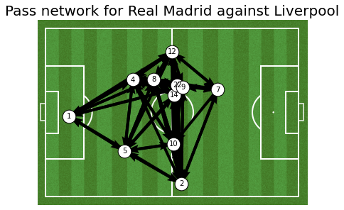

```python
pitch = Pitch(pitch_color='grass', goal_type = 'box', line_color='white', stripe = True,
              constrained_layout=True, tight_layout=False)
fig, ax = pitch.draw()
arrows = pitch.arrows(pass_Real.pass_maker_x, pass_Real.pass_maker_y,
                         pass_Real.pass_receiver_x, pass_Real.pass_receiver_y, lw = 5,
                         color = 'black', zorder = 1, ax=ax)
nodes = pitch.scatter(av_loc_Real.pass_maker_x, av_loc_Real.pass_maker_y,
                           s=350, color = 'white', edgecolors='black', linewidth=1, alpha = 1, ax = ax)

for index, row in av_loc_Real.iterrows():
    pitch.annotate(players_Real[row.name], xy=(row.pass_maker_x, row.pass_maker_y),
                   c ='black', va = 'center', ha = 'center', size = 10, ax = ax)
plt.title("Pass network for Real Madrid against Liverpool", size = 20)
plt.show()
```

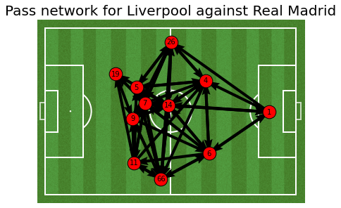

```python
pitch = Pitch(pitch_color='grass', goal_type = 'box', stripe = True,
              line_color='white', constrained_layout=True, tight_layout=False)
fig, ax = pitch.draw()
arrows = pitch.arrows(120 - pass_Liv.pass_maker_x, pass_Liv.pass_maker_y,
                         120 - pass_Liv.pass_receiver_x, pass_Liv.pass_receiver_y, lw = 5,
                         color = 'black', zorder = 1, ax = ax)
nodes = pitch.scatter(120 - av_loc_Liv.pass_maker_x, av_loc_Liv.pass_maker_y,
                           s=350, color = 'red', edgecolors = 'black', linewidth=1, alpha = 1, ax = ax)

for index, row in av_loc_Liv.iterrows():
    pitch.annotate(players_Liv[row.name], xy=(120 - row.pass_maker_x, row.pass_maker_y),
                   c ='black', va = 'center', ha = 'center', size = 10, ax = ax)
plt.title("Pass network for Liverpool against Real Madrid", size = 20)
plt.show()
```

- In case of `Liverpool`'s pass network visualization, we subtract the x coordinates from 120 just to reverse the x-axis.
- Now that we have been successful in correctly visualizing the pass networks of the teams involved in the game, we will now start analyzing our networks using metrics from the literature of *complex network analysis*.
- Note that both of our networks are directed weighted graphs, with number of passes as the weight for a directed edge.
- Let us first develop the isomorphic graph to the one we just visualized for `Real Madrid`, but this time using the `networkx` package. First we will use the relevant columns from the `pass_Real_new` dataset:

```python
pass_Real_new = pass_Real_new[['pass_maker', 'pass_receiver', 'number_of_passes']]
pass_Real_new
```

|  | pass_maker | pass_receiver | number_of_passes |
| --- | --- | --- | --- |
| 0 | 14 | 2 | 1 |
| 1 | 7 | 2 | 3 |
| 2 | 22 | 2 | 2 |
| 3 | 9 | 2 | 2 |
| 4 | 10 | 2 | 10 |
| ... | ... | ... | ... |
| 73 | 2 | 1 | 1 |
| 74 | 9 | 1 | 1 |
| 75 | 5 | 1 | 2 |
| 76 | 4 | 1 | 1 |
| 77 | 8 | 1 | 1 |

78 rows × 3 columns

- We will next convert `pass_Real_new` to a list of tuples, where each row is converted to a tuple. This is required for drawing a `networkx` graph.

```python
L_Real = pass_Real_new.apply(tuple, axis=1).tolist()
print(L_Real)
```

```
[('14', '2', 1), ('7', '2', 3), ('22', '2', 2), ('9', '2', 2), ('10', '2', 10), ('12', '2', 2), ('5', '2', 3), ('4', '2', 3), ('8', '2', 1), ('14', '10', 1), ('7', '10', 1), ('2', '10', 7), ('22', '10', 1), ('12', '10', 1), ('5', '10', 5), ('4', '10', 2), ('8', '10', 5), ('14', '12', 1), ('7', '12',…
```

- Now, we can draw the directed weighted graph:

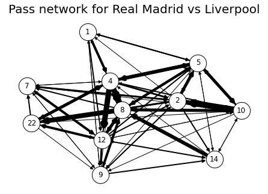

```python
G_Real = nx.DiGraph()

for i in range(len(L_Real)):
    G_Real.add_edge(L_Real[i][0], L_Real[i][1], weight = L_Real[i][2])

edges_Real = G_Real.edges()
weights_Real = [G_Real[u][v]['weight'] for u, v in edges_Real]

nx.draw(G_Real, node_size=800, with_labels=True, node_color='white', width = weights_Real)
plt.gca().collections[0].set_edgecolor('black') # sets the edge color of the nodes to black
plt.title("Pass network for Real Madrid vs Liverpool", size = 20)
plt.show()
```

- Now for `Liverpool` too, let us first clean the `pass_Liv_new` dataset and then draw the isomorphic weighted directed graph:

```python
pass_Liv_new = pass_Liv_new[['pass_maker', 'pass_receiver', 'number_of_passes']]
```

```python
pass_Liv_new
```

|  | pass_maker | pass_receiver | number_of_passes |
| --- | --- | --- | --- |
| 0 | 5 | 26 | 4 |
| 1 | 7 | 26 | 1 |
| 2 | 14 | 26 | 1 |
| 3 | 1 | 26 | 1 |
| 4 | 66 | 26 | 1 |
| ... | ... | ... | ... |
| 59 | 66 | 6 | 1 |
| 60 | 4 | 6 | 3 |
| 61 | 7 | 19 | 2 |
| 62 | 14 | 19 | 1 |
| 63 | 11 | 19 | 1 |

64 rows × 3 columns

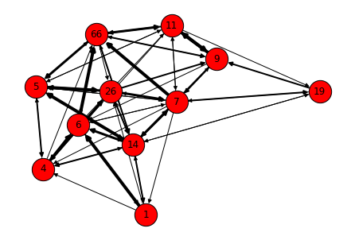

```python
L_Liv = pass_Liv_new.apply(tuple, axis=1).tolist()
G_Liv = nx.DiGraph()

for i in range(len(L_Liv)):
    G_Liv.add_edge(L_Liv[i][0], L_Liv[i][1], weight = L_Liv[i][2])

edges_Liv = G_Liv.edges()
weights_Liv = [G_Liv[u][v]['weight'] for u, v in edges_Liv]

nx.draw(G_Liv, node_size = 800, with_labels = True, node_color = 'red', width = weights_Liv)
plt.gca().collections[0].set_edgecolor('black') # sets the edge color of the nodes to black
plt.show()
```

We will use `networkx` to find out the node degrees from the pass network of `Real Madrid`.

```python
# Prepare a dictionary with jersey numbers as the node ids,
# i.e, the dictionary keys and degrees as the dictionary values
deg_Real = dict(nx.degree(G_Real))
# convert a dictionary to a pandas dataframe
degree_Real = pd.DataFrame.from_dict(list(deg_Real.items()))
degree_Real.rename(columns = {0:'jersey_number', 1: 'node_degree'}, inplace = True)
```

```python
degree_Real
```

|  | jersey_number | node_degree |
| --- | --- | --- |
| 0 | 14 | 12 |
| 1 | 2 | 17 |
| 2 | 7 | 11 |
| 3 | 22 | 11 |
| 4 | 9 | 14 |
| 5 | 10 | 15 |
| 6 | 12 | 16 |
| 7 | 5 | 14 |
| 8 | 4 | 17 |
| 9 | 8 | 19 |
| 10 | 1 | 10 |

- Out of the 11 starting players for `Real Madrid` in that game, we notice that the player with jersey number `8` (i.e, `Toni Kroos`) had the highest *degree* value of 19. On second are ranked the players with jersey number `2` and `4` with degree value 17, i.e, our favorite Spanish defenders `'Daniel Carvajal Ramos'` and `'Sergio Ramos García'` respectively. Tremendous! Let us use `seaborn` to visualize the `deg_Real` dictionary via histogram plot:

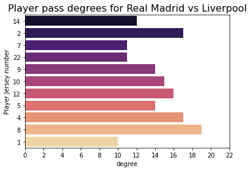

```python
X = list(deg_Real.keys())
Y = list(deg_Real.values())
sns.barplot(x = Y, y = X, palette = "magma")
plt.xticks(range(0, max(Y)+5, 2))
plt.ylabel("Player Jersey number")
plt.xlabel("degree")
plt.title("Player pass degrees for Real Madrid vs Liverpool", size = 16)
plt.show()
```

- Let us build the dataframe for `Liverpool` too:

```python
# Prepare a dictionary with jersey numbers as the node ids,
# i.e, the dictionary keys and degrees as the dictionary values
deg_Liv = dict(nx.degree(G_Liv))
# convert a dictionary to a pandas dataframe
degree_Liv = pd.DataFrame.from_dict(list(deg_Liv.items()))
degree_Liv.rename(columns = {0:'jersey_number', 1: 'node_degree'}, inplace = True)
degree_Liv
```

|  | jersey_number | node_degree |
| --- | --- | --- |
| 0 | 5 | 12 |
| 1 | 26 | 11 |
| 2 | 7 | 17 |
| 3 | 14 | 17 |
| 4 | 1 | 7 |
| 5 | 66 | 13 |
| 6 | 4 | 12 |
| 7 | 11 | 11 |
| 8 | 6 | 12 |
| 9 | 9 | 10 |
| 10 | 19 | 6 |

- We see that for Liverpool the degree value is highest (17) for players having jersey number `14` and `7`, i,e `'Jordan Brian Henderson'` and `'James Philip Milner'` respectively. We will visualize the `deg_Liv` dictionary via histogram plot:

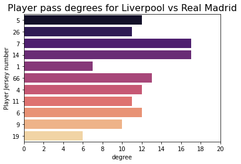

```python
X = list(deg_Liv.keys())
Y = list(deg_Liv.values())
sns.barplot(x = Y, y = X, palette = "magma")
plt.xticks(range(0, max(Y)+5, 2))
plt.ylabel("Player Jersey number")
plt.xlabel("degree")
plt.title("Player pass degrees for Liverpool vs Real Madrid", size = 16)
plt.show()
```

- We will visualize similar histogram plots for the *indegrees* and the *outdegrees* too:

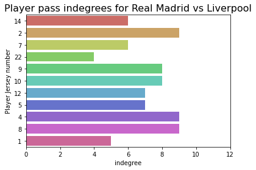

```python
indeg_Real = dict(G_Real.in_degree())
indegree_Real = pd.DataFrame.from_dict(list(indeg_Real.items()))
indegree_Real.rename(columns = {0:'jersey_number', 1: 'node_indegree'}, inplace = True)
X = list(indeg_Real.keys())
Y = list(indeg_Real.values())
sns.barplot(x = Y, y = X, palette = "hls")
plt.xticks(range(0, max(Y)+5, 2))
plt.ylabel("Player Jersey number")
plt.xlabel("indegree")
plt.title("Player pass indegrees for Real Madrid vs Liverpool", size = 16)
plt.show()
```

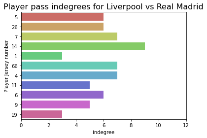

```python
indeg_Liv = dict(G_Liv.in_degree())
indegree_Liv = pd.DataFrame.from_dict(list(indeg_Liv.items()))
indegree_Liv.rename(columns = {0:'jersey_number', 1: 'node_indegree'}, inplace = True)
X = list(indeg_Liv.keys())
Y = list(indeg_Liv.values())
sns.barplot(x = Y, y = X, palette = "hls")
plt.xticks(range(0, max(Y)+5, 2))
plt.ylabel("Player Jersey number")
plt.xlabel("indegree")
plt.title("Player pass indegrees for Liverpool vs Real Madrid", size = 16)
plt.show()
```

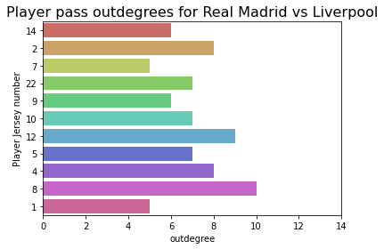

```python
outdeg_Real = dict(G_Real.out_degree())
outdegree_Real = pd.DataFrame.from_dict(list(outdeg_Real.items()))
outdegree_Real.rename(columns = {0:'jersey_number', 1: 'node_outdegree'}, inplace = True)
X = list(outdeg_Real.keys())
Y = list(outdeg_Real.values())
sns.barplot(x = Y, y = X, palette = "hls")
plt.xticks(range(0, max(Y)+5, 2))
plt.ylabel("Player Jersey number")
plt.xlabel("outdegree")
plt.title("Player pass outdegrees for Real Madrid vs Liverpool", size = 16)
plt.show()
```

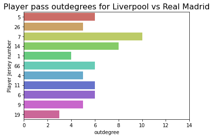

```python
outdeg_Liv = dict(G_Liv.out_degree())
outdegree_Liv = pd.DataFrame.from_dict(list(outdeg_Liv.items()))
outdegree_Liv.rename(columns = {0:'jersey_number', 1: 'node_outdegree'}, inplace = True)
X = list(outdeg_Liv.keys())
Y = list(outdeg_Liv.values())
sns.barplot(x = Y, y = X, palette = "hls")
plt.xticks(range(0, max(Y)+5, 2))
plt.ylabel("Player Jersey number")
plt.xlabel("outdegree")
plt.title("Player pass outdegrees for Liverpool vs Real Madrid", size = 16)
plt.show()
```

- Now, let us generate the adjacency matrices fr both `G_Real` and `G_Liv` graphs:

```python
A_Real = nx.adjacency_matrix(G_Real)
A_Liv = nx.adjacency_matrix(G_Liv)
A_Real = A_Real.todense()
A_Liv = A_Liv.todense()
```

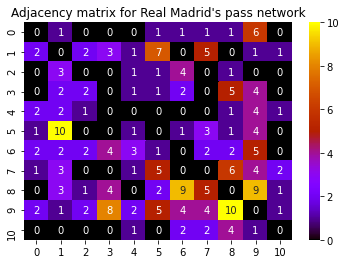

```python
sns.heatmap(A_Real, annot = True, cmap ='gnuplot')
plt.title("Adjacency matrix for Real Madrid's pass network")
plt.show()
```

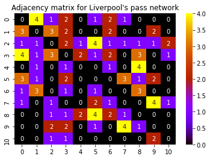

```python
sns.heatmap(A_Liv, annot = True, cmap ='gnuplot')
plt.title("Adjacency matrix for Liverpool's pass network")
plt.show()
```

- If we look into the diagonal of the adjacency matrices, we notice that all the values in the diagonals are 0. This depicts that their isn't any self loops in any nodes, indicating a player cannot pass to themselves.
- The next step is to calculate the degree correlation coefficient of a graph. More specifically, we will calculate *Pearson's degree correlation coefficient* value. A positive value of the metric shows an overall positive relationship between the degrees (number of successful passes) of two adjacent nodes (players). Whereas a negative value shows an overall negative relationship. If it is 0, there is no relationship. Also the metric lies in [-1, 1], indicating -1 as the prefect negative relationship and 1 as the perfect positive relationship.

```python
r_Real = nx.degree_pearson_correlation_coefficient(G_Real, weight = 'weight')
r_Liv = nx.degree_pearson_correlation_coefficient(G_Liv, weight = 'weight')
print(r_Real, r_Liv)
```

```
-0.17983836432860179 -0.2412372196699064
```

- Now we work on a metric that focuses on the geodesic distance between two player nodes in a graph. One way to implement this is to divide 1 by the `'weight'` column in the pass network. Let us create a new graph for `Real Madrid`:

```python
pass_Real_mod = pass_Real_new[['pass_maker', 'pass_receiver']]
pass_Real_mod['1/nop'] = 1/pass_Real_new['number_of_passes']
pass_Real_mod.head(5)
```

|  | pass_maker | pass_receiver | 1/nop |
| --- | --- | --- | --- |
| 0 | 14 | 2 | 1.000000 |
| 1 | 7 | 2 | 0.333333 |
| 2 | 22 | 2 | 0.500000 |
| 3 | 9 | 2 | 0.500000 |
| 4 | 10 | 2 | 0.100000 |

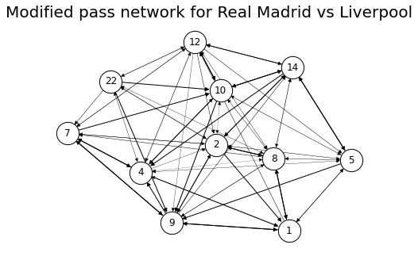

```python
L_Real_mod = pass_Real_mod.apply(tuple, axis=1).tolist()

G_Real_mod = nx.DiGraph()

for i in range(len(L_Real_mod)):
    G_Real_mod.add_edge(L_Real_mod[i][0], L_Real_mod[i][1], weight = L_Real_mod[i][2])

edges_Real_mod = G_Real_mod.edges()
weights_Real_mod = [G_Real_mod[u][v]['weight'] for u, v in edges_Real_mod]

nx.draw(G_Real_mod, node_size=800, with_labels=True, node_color='white', width = weights_Real_mod)
plt.gca().collections[0].set_edgecolor('black')
plt.title("Modified pass network for Real Madrid vs Liverpool", size = 20)

plt.show()
```

- We will perform the same operations to create a modified graph for `Liverpool` too:

```python
pass_Liv_mod = pass_Liv_new[['pass_maker', 'pass_receiver']]
pass_Liv_mod['1/nop'] = 1/pass_Liv_new['number_of_passes']
pass_Liv_mod.head(5)
```

|  | pass_maker | pass_receiver | 1/nop |
| --- | --- | --- | --- |
| 0 | 5 | 26 | 0.25 |
| 1 | 7 | 26 | 1.00 |
| 2 | 14 | 26 | 1.00 |
| 3 | 1 | 26 | 1.00 |
| 4 | 66 | 26 | 1.00 |

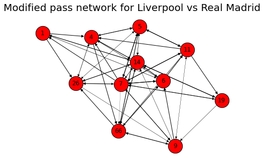

```python
L_Liv_mod = pass_Liv_mod.apply(tuple, axis=1).tolist()

G_Liv_mod = nx.DiGraph()

for i in range(len(L_Liv_mod)):
    G_Liv_mod.add_edge(L_Liv_mod[i][0], L_Liv_mod[i][1], weight = L_Liv_mod[i][2])

edges_Liv_mod = G_Liv_mod.edges()
weights_Liv_mod = [G_Liv_mod[u][v]['weight'] for u, v in edges_Liv_mod]

nx.draw(G_Liv_mod, node_size=800, with_labels=True, node_color='red', width = weights_Liv_mod)
plt.gca().collections[0].set_edgecolor('black')
plt.title("Modified pass network for Liverpool vs Real Madrid", size = 20)

plt.show()
```

- Now using these modified graphs we can calculate the all pair shortest paths between the nodes (players) for both the teams. Let us compute first for `Real Madrid`:

```python
dis_Real = nx.shortest_path(G_Real_mod, weight = 'weight')
print(dis_Real)
```

```
{'14': {'14': ['14'], '2': ['14', '8', '10', '2'], '10': ['14', '8', '10'], '12': ['14', '8', '4', '12'], '5': ['14', '8', '5'], '4': ['14', '8', '4'], '8': ['14', '8'], '9': ['14', '8', '9'], '7': ['14', '8', '7'], '22': ['14', '8', '22'], '1': ['14', '8', '5', '1']}, '2': {'2': ['2'], '10': ['2', …
```

- Suppose we want to calculate the shortest path from `'Keylor Navas Gamboa'` (jersey number `1`) to `'Cristiano Ronaldo dos Santos Aveiro'` (jersey number `7`). We will type the following:

```python
print(dis_Real['1']['7'])
```

```
['1', '4', '12', '7']
```

- So, we see that the fastest way possible to pass the ball from `'Keylor Navas Gamboa'` (jersey: `1`), to `'Cristiano Ronaldo dos Santos Aveiro'` (jersey: `7`) was to pass the ball first to `'Sergio Ramos García'` (jersey: `4`) who would pass to `'Marcelo Vieira da Silva Júnior'` (jersey: `12`) with him ultimately passing to `'Cristiano Ronaldo dos Santos Aveiro'`. This seems like a good post-match analysis tool. I got this idea after discussing with [Sarath Babu](https://4sarathbabu.github.io/).
- Let us do the same analysis for `Liverpool`:

```python
dis_Liv = nx.shortest_path(G_Liv_mod, weight = 'weight')
print(dis_Liv)
```

```
{'5': {'5': ['5'], '26': ['5', '26'], '7': ['5', '26', '7'], '14': ['5', '14'], '4': ['5', '4'], '11': ['5', '11'], '66': ['5', '26', '7', '66'], '9': ['5', '26', '9'], '1': ['5', '14', '1'], '6': ['5', '14', '6'], '19': ['5', '26', '7', '19']}, '26': {'26': ['26'], '5': ['26', '5'], '7': ['26', '7'…
```

```python
print(dis_Liv['1']['9'])
```

```
['1', '6', '66', '9']
```

- Now we will calculate another important metric called *eccentricity*, which is based on shortest distance. *Eccentricity* of a player node `p` tells us how far the furthest player node from `p` is positioned in the pass network. Let us calculate the eccentricities for all the 11 nodes for `Real Madrid`.

```python
E_Real = nx.eccentricity(G_Real_mod)
print(E_Real)
```

```
{'14': 2, '2': 2, '7': 2, '22': 2, '9': 2, '10': 2, '12': 2, '5': 2, '4': 2, '8': 1, '1': 2}
```

- We can calculate the average eccentricity:

```python
av_E_Real = sum(list(E_Real.values()))/len(E_Real)
print(av_E_Real)
```

```
1.9090909090909092
```

- For `Liverpool`:

```python
E_Liv = nx.eccentricity(G_Liv_mod)
print(E_Liv)
```

```
{'5': 2, '26': 2, '7': 1, '14': 2, '1': 2, '66': 2, '4': 2, '11': 2, '6': 2, '9': 2, '19': 2}
```

- We can calculate the *average eccentricity*:

```python
av_E_Liv = sum(list(E_Liv.values()))/len(E_Liv)
print(av_E_Liv)
```

```
1.9090909090909092
```

- We can also calculate the *average clustering coefficient* of a graph. Let us first compute this metric for `G_Real` (note that this graph should not be the modified version)

```python
cc_Real = nx.average_clustering(G_Real, weight = 'weight')
print(cc_Real)
```

```
0.182334851979709
```

- for `Liverpool`:

```python
cc_Liv = nx.average_clustering(G_Liv, weight = 'weight')
print(cc_Liv)
```

```
0.2766427842450553
```

- The *average clustering coefficient* lies in the range [0, 1] where, a value of 0 denotes the fact that none of the nodes are connected to each other and a value of 1 denotes that the network is a clique, that is each node is connected to all the other nodes of the network. We see that interestingly the *average clustering coefficient* is lesser for `Real Madrid`'s pass network stating the fact that a lesser number of players passed the ball among each other, compared to that of `Liverpool`.
- Finally, we can compute the `centrality` (especially the `betweenness centrality`) for each node in either team's pass network and understand which player was the most important in their pass network. For `Real Madrid`:

```python
bc_Real = nx.betweenness_centrality(G_Real, weight = 'weight')
print(bc_Real)
```

```
{'14': 0.15222222222222223, '2': 0.10685185185185186, '7': 0.05592592592592593, '22': 0.0, '9': 0.14462962962962964, '10': 0.12407407407407407, '12': 0.009259259259259259, '5': 0.007407407407407408, '4': 0.06851851851851852, '8': 0.031481481481481485, '1': 0.11703703703703704}
```

- we can find the node which has the maximum *betweenness centrality* measure.

```python
max_bc_Real = max(bc_Real, key = bc_Real.get)
print(max_bc_Real)
```

```
14
```

- For `Liverpool`:

```python
bc_Liv = nx.betweenness_centrality(G_Liv, weight = 'weight')
print(bc_Liv)
max_bc_Liv = max(bc_Liv, key = bc_Liv.get)
print(max_bc_Liv)
```

```
{'5': 0.06296296296296296, '26': 0.016666666666666666, '7': 0.2453703703703704, '14': 0.12407407407407407, '1': 0.002777777777777778, '66': 0.075, '4': 0.07222222222222222, '11': 0.05555555555555556, '6': 0.1259259259259259, '9': 0.021296296296296296, '19': 0.03888888888888889}
7
```

## Refrences

- [**FCPython Blog**](https://fcpython.com/),
- Book [**Soccermatics**](https://www.amazon.co.uk/Soccermatics-Mathematical-Adventures-Pro-Bloomsbury/dp/1472924142/ref=tmm_pap_swatch_0?_encoding=UTF8&qid=&sr=) by Dr. David Sumpter,
- [**Friends of Tracking**](https://www.youtube.com/channel/UCUBFJYcag8j2rm_9HkrrA7w) youtube channel managed by Dr. Sumpter,
- Youtube channel by [**McKay Johns**](https://www.youtube.com/channel/UCmqincDKps3syxvD4hbODSg), and
- Book [**Graph Theory and Complex Networks: An Introduction**](https://www.amazon.com/Graph-Theory-Complex-Networks-Introduction/dp/9081540610) by Dr. Maarten van Steen